# Simulation Project

Chaoran Zhou

# Simulation Study 1: Significance of Regression

**Introduction**

In this simulation study we will investigate the significance of regression test. We will simulate from two different models:

1. The **“significant”** model

$$Y_i = \beta_0 + \beta_1 x_{i1} + \beta_2 x_{i2} + \beta_3 x_{i3} +
\epsilon_i$$

where $\epsilon_i \sim N(0, \sigma^2)$ and

- $\beta_0 = 3$,
- $\beta_1 = 1$,
- $\beta_2 = 1$,
- $\beta_3 = 1$.
2. The **“non-significant”** model

$$Y_i = \beta_0 + \beta_1 x_{i1} + \beta_2 x_{i2} + \beta_3 x_{i3} +
\epsilon_i$$

where $\epsilon_i \sim N(0, \sigma^2)$ and

- $\beta_0 = 3$,
- $\beta_1 = 0$,
- $\beta_2 = 0$,
- $\beta_3 = 0$.

For both, we will consider a sample size of $25$ and three possible levels of noise. That is, three values of $\sigma$.

- $n = 25$
- $\sigma \in (1, 5, 10)$

We will use simulation to obtain an empirical distribution for each of the following values, for each of the three values of $\sigma$, for both models.

- The **$F$ statistic** for the significance of regression test.
- The **p-value** for the significance of regression test
- **$R^2$**

For each model and $\sigma$ combination, we will use $2000$ simulations. For each simulation, we will fit a regression model of the same form used to perform the simulation.

We will use the data found in `study_1.csv` for the values of the predictors. These will be kept constant for the entirety of this study. The `y` values in this data are a blank placeholder.

We will have simulated the `y` vector $2 (models)×3 (sigmas)×2000 (sims)=12000$ times.

**Methods**

```r
#setting seed
birthday = 19910130
set.seed(birthday)

#Importing data file for this simulation study
library(readr)
study_1 = read_csv("study_1.csv")

sample_size = 25

# set parameter for significant model
beta_0_sig = 3
beta_1_sig = 1
beta_2_sig = 1
beta_3_sig = 1
num_sim = 2000

x0 = rep(1, sample_size)

sigmas = list(1, 5, 10)

# function to simulate the data
library(broom)
sim_anova = function(study_1,
                     x0,
                     n,
                     beta_0,
                     beta_1,
                     beta_2,
                     beta_3,
                     sigma) {
  study_1$y = beta_0 * x0  + beta_1 * study_1[[2]] + beta_2 * study_1[[3]] + beta_3 * study_1[[4]] + rnorm(n, mean = 0, sd = sigma)
  model = lm(y ~ ., data = study_1)

  list(
    r_squ = glance(model)$r.squared,
    f_stat = glance(model)$statistic[[1]],
    p_val = glance(model)$p.value[[1]]
  )
}



# perform simulation with the $\sigma$ value of 1, 5, 10.

# use replicate to simulate 1000 times for sigma = 1
sig_stat_1 = replicate(
  n = num_sim,
  sim_anova(
    study_1,
    x0,
    sample_size,
    beta_0_sig,
    beta_1_sig,
    beta_2_sig,
    beta_3_sig,
    sigmas[[1]]
  )
)

#Storing results in data frame
r_2_1 = do.call(rbind, sig_stat_1[1,])
f_1 = do.call(rbind, sig_stat_1[2,])
p_1 = do.call(rbind, sig_stat_1[3,])

result_sigma1 = data.frame(r_squared = r_2_1,
                           f_statistic = f_1,
                           p_value = p_1)


# use replicate to simulate 1000 times for sigma = 5
sig_stat_2 = replicate(
  n = num_sim,
  sim_anova(
    study_1,
    x0,
    sample_size,
    beta_0_sig,
    beta_1_sig,
    beta_2_sig,
    beta_3_sig,
    sigmas[[2]]
  )
)

#Storing results in data frame
r_2_2 = do.call(rbind, sig_stat_2[1,])
f_2 = do.call(rbind, sig_stat_2[2,])
p_2 = do.call(rbind, sig_stat_2[3,])
result_sigma2 = data.frame(r_squared = r_2_2,
                           f_statistic = f_2,
                           p_value = p_2)


# use replicate to simulate 1000 times for sigma = 10
sig_stat_3 = replicate(
  n = num_sim,
  sim_anova(
    study_1,
    x0,
    sample_size,
    beta_0_sig,
    beta_1_sig,
    beta_2_sig,
    beta_3_sig,
    sigmas[[3]]
  )
)

#Storing results in data frame
r_2_3 = do.call(rbind, sig_stat_3[1,])
f_3 = do.call(rbind, sig_stat_3[2,])
p_3 = do.call(rbind, sig_stat_3[3,])

result_sigma3 = data.frame(r_squared = r_2_3,
                           f_statistic = f_3,
                           p_value = p_3)
```

```r
# set parameter for non-significant model
beta_0_non = 3
beta_1_non = 0
beta_2_non = 0
beta_3_non = 0

# perform simulation with the $\sigma$ value of 1, 5, 10.

# use replicate to simulate 1000 times for sigma = 1
sig_stat_1_non = replicate(
  n = num_sim,
  sim_anova(
    study_1,
    x0,
    sample_size,
    beta_0_non,
    beta_1_non,
    beta_2_non,
    beta_3_non,
    sigmas[[1]]
  )
)

#Storing results in data frame
r_2_1_non = do.call(rbind, sig_stat_1_non[1,])
f_1_non = do.call(rbind, sig_stat_1_non[2,])
p_1_non = do.call(rbind, sig_stat_1_non[3,])
#Storing results in data frame
result_sigma1_non = data.frame(r_squared = r_2_1_non,
                               f_statistic = f_1_non,
                               p_value = p_1_non)

# use replicate to simulate 1000 times for sigma = 5
sig_stat_2_non = replicate(
  n = num_sim,
  sim_anova(
    study_1,
    x0,
    sample_size,
    beta_0_non,
    beta_1_non,
    beta_2_non,
    beta_3_non,
    sigmas[[2]]
  )
)

#Storing results in data frame
r_2_2_non = do.call(rbind, sig_stat_2_non[1,])
f_2_non = do.call(rbind, sig_stat_2_non[2,])
p_2_non = do.call(rbind, sig_stat_2_non[3,])
#Storing results in data frame

result_sigma2_non = data.frame(r_squared = r_2_2_non,
                               f_statistic = f_2_non,
                               p_value = p_2_non)


# use replicate to simulate 1000 times for sigma = 10
sig_stat_3_non = replicate(
  n = num_sim,
  sim_anova(
    study_1,
    x0,
    sample_size,
    beta_0_non,
    beta_1_non,
    beta_2_non,
    beta_3_non,
    sigmas[[3]]
  )
)

#Storing results in data frame
r_2_3_non = do.call(rbind, sig_stat_3_non[1,])
f_3_non = do.call(rbind, sig_stat_3_non[2,])
p_3_non = do.call(rbind, sig_stat_3_non[3,])
#Storing results in data frame

result_sigma3_non = data.frame(r_squared = r_2_3_non,
                               f_statistic = f_3_non,
                               p_value = p_3_non)
```

We plot the test static distribution for each model each sigma. A $1 × 3$ row of $F$ statistic plots as $\sigma$ changes, then a $1 × 3$ row of $p$-value plots as $\sigma$ changes, followed by a similar row for the $R^2$ values. One for the values attributed to the significant model and one for the nonsignificant model.

```r
#Setting placeholder frames for plots
par(mfrow = c(3, 3))

library(sadists)
#plots for significant model f statistic

hist(
  result_sigma1$f_statistic,
  col = "orange",
  main = expression(
    paste("Distribution of significant model F-statistic for ", sigma, " = 1")
  ),
  xlab = expression(f[statistic]),
  border = "blue",
  prob = TRUE,
  ylim = c(0.000, 0.035),
  cex.axis = 2,
  cex.lab = 2,
  cex.main = 2.5
)


hist(
  result_sigma2$f_statistic,
  col = "orange",
  main =  expression(
    paste("Distribution of significant model F-statistic for ", sigma, " = 5")
  ),
  xlab = expression(f[statistic]),
  border = "blue",
  prob = TRUE,
  ylim = c(0.000, 0.80),
  cex.axis = 2,
  cex.lab = 2,
  cex.main = 2.5
)


hist(
  result_sigma3$f_statistic,
  col = "orange",
  main =  expression(
    paste("Distribution of significant model F-statistic for ", sigma, " = 10")
  ),
  xlab = expression(f[statistic]),
  border = "blue",
  prob = TRUE,
  ylim = c(0.000, 0.80),
  cex.axis = 2,
  cex.lab = 2,
  cex.main = 2.5
)


#plots for significant model p value
hist(
  result_sigma1$p_value,
  col = "lightblue",
  main = expression(
    paste("Distribution of significant model p-value for ", sigma, " = 1")
  ),
  xlab = expression(p - value),
  border = "blue",
  prob = TRUE,
  cex.axis = 2,
  cex.lab = 2,
  cex.main = 2.5
)
#qf(x, df1 = 3, df2 = 21, lower.tail=FALSE),

hist(
  result_sigma2$p_value,
  col = "lightblue",
  main = expression(
    paste("Distribution of significant model p-value for ", sigma, " = 5")
  ),
  xlab = expression(p - value),
  border = "blue",
  prob = TRUE,
  cex.axis = 2,
  cex.lab = 2,
  cex.main = 2.5
)


hist(
  result_sigma3$p_value,
  col = "lightblue",
  main = expression(
    paste("Distribution of significant model p-value for ", sigma, " = 10")
  ),
  xlab = expression(p - value),
  border = "blue",
  prob = TRUE,
  cex.axis = 2,
  cex.lab = 2,
  cex.main = 2.5
)

#plots for significant model r.square
hist(
  result_sigma1$r_squared,
  breaks = 20,
  main = expression(
    paste("Distribution of significant model R-squared for ", sigma, " = 1")
  ),
  xlab = expression(R ^ 2),
  border = "dodgerblue",
  prob = TRUE,
  cex.axis = 2,
  cex.lab = 2,
  cex.main = 2.5
)


hist(
  result_sigma2$r_squared,
  breaks = 20,
  main = expression(
    paste("Distribution of significant model R-squared for ", sigma, " = 5")
  ),
  xlab = expression(R ^ 2),
  border = "dodgerblue",
  prob = TRUE,
  cex.axis = 2,
  cex.lab = 2,
  cex.main = 2.5
)


hist(
  result_sigma3$r_squared,
  breaks = 20,
  main = expression(
    paste("Distribution of significant model R-squared for ", sigma, " = 10")
  ),
  xlab = expression(R ^ 2),
  border = "dodgerblue",
  prob = TRUE,
  cex.axis = 2,
  cex.lab = 2,
  cex.main = 2.5
)

par(mfrow = c(3, 3))
#plots for non-significant model f statistic
hist(
  result_sigma1_non$f_statistic,
  col = "orange",
  main = expression(
    paste(
      "Distribution of non-significant model F-statistic for ",
      sigma,
      " = 1"
    )
  ),
  xlab = expression(f[statistic]),
  border = "blue",
  prob = TRUE,
  ylim = c(0.000, 0.80),
  cex.axis = 2,
  cex.lab = 2,
  cex.main = 2.5
)
curve(
  df(x, df1 = 3, df2 = 21),
  from = 0,
  to = 15,
  n = 200,
  col = 'limegreen',
  lwd = 2,
  add = TRUE
)
legend(
  "topright",
  c("True distribution"),
  lty = c(1, 2),
  lwd = 2,
  col = c("limegreen"),
  cex = 2,
  pt.cex = 3
)

hist(
  result_sigma2_non$f_statistic,
  col = "orange",
  main =  expression(
    paste(
      "Distribution of non-significant model F-statistic for ",
      sigma,
      " = 5"
    )
  ),
  xlab = expression(f[statistic]),
  border = "blue",
  prob = TRUE,
  ylim = c(0.000, 0.80),
  cex.axis = 2,
  cex.lab = 2,
  cex.main = 2.5
)
curve(
  df(x, df1 = 3, df2 = 21),
  from = 0,
  to = 7,
  n = 200,
  col = 'limegreen',
  lwd = 2,
  add = TRUE
)
legend(
  "topright",
  c("True distribution"),
  lty = c(1, 2),
  lwd = 2,
  col = c("limegreen"),
  cex = 2,
  pt.cex = 3
)

hist(
  result_sigma3_non$f_statistic,
  col = "orange",
  main =  expression(
    paste(
      "Distribution of non-significant model F-statistic for ",
      sigma,
      " = 10"
    )
  ),
  xlab = expression(f[statistic]),
  border = "blue",
  prob = TRUE,
  ylim = c(0.000, 0.80),
  cex.axis = 2,
  cex.lab = 2,
  cex.main = 2.5
)
curve(
  df(x, df1 = 3, df2 = 21),
  from = 0,
  to = 12,
  n = 200,
  col = 'limegreen',
  lwd = 2,
  add = TRUE
)
legend(
  "topright",
  c("True distribution"),
  lty = c(1, 2),
  lwd = 2,
  col = c("limegreen"),
  cex = 2,
  pt.cex = 3
)

#plots for non-significant model p value
hist(
  result_sigma1_non$p_value,
  col = "lightblue",
  main = expression(
    paste("Distribution of non-significant model p-value for ", sigma, " = 1")
  ),
  xlab = expression(p - value),
  border = "blue",
  prob = TRUE,
  cex.axis = 2,
  cex.lab = 2,
  cex.main = 2.5
)
curve(
  dunif(x, min = 0, max = 1),
  col = 'red',
  lwd = 2,
  add = TRUE
)
legend(
  "topright",
  c("True distribution"),
  lty = c(1, 2),
  lwd = 2,
  col = c("red"),
  cex = 2,
  pt.cex = 3
)

hist(
  result_sigma2_non$p_value,
  col = "lightblue",
  main = expression(
    paste("Distribution of non-significant model p-value for ", sigma, " = 5")
  ),
  xlab = expression(p - value),
  border = "blue",
  prob = TRUE,
  cex.axis = 2,
  cex.lab = 2,
  cex.main = 2.5
)
curve(
  dunif(x, min = 0, max = 1),
  col = 'red',
  lwd = 2,
  add = TRUE
)
legend(
  "topright",
  c("True distribution"),
  lty = c(1, 2),
  lwd = 2,
  col = c("red"),
  cex = 2,
  pt.cex = 3
)

hist(
  result_sigma3_non$p_value,
  col = "lightblue",
  main = expression(
    paste("Distribution of non-significant model p-value for ", sigma, " = 10")
  ),
  xlab = expression(p - value),
  border = "blue",
  prob = TRUE,
  cex.axis = 2,
  cex.lab = 2,
  cex.main = 2.5
)
curve(
  dunif(x, min = 0, max = 1),
  col = 'red',
  lwd = 2,
  add = TRUE
)
legend(
  "topright",
  c("True distribution"),
  lty = c(1, 2),
  lwd = 2,
  col = c("red"),
  cex = 2,
  pt.cex = 3
)

# plots for non-significant model r.square
hist(
  result_sigma1_non$r_squared,
  breaks = 20,
  main = expression(
    paste(
      "Distribution of non-significant model R-squared for ",
      sigma,
      " = 1"
    )
  ),
  xlab = expression(R ^ 2),
  border = "dodgerblue",
  prob = TRUE,
  cex.axis = 2,
  cex.lab = 2,
  cex.main = 2.5
)
curve(
  dbeta(x, 1.5, 10.5),
  from = 0,
  to = 0.6,
  n = 500,
  col = 'purple',
  lwd = 2,
  add = TRUE
)
legend(
  "topright",
  c("True distribution"),
  lty = c(1, 2),
  lwd = 2,
  col = c('purple'),
  cex = 2,
  pt.cex = 3
)



hist(
  result_sigma2_non$r_squared,
  breaks = 20,
  main = expression(
    paste(
      "Distribution of non-significant model R-squared for ",
      sigma,
      " = 5"
    )
  ),
  xlab = expression(R ^ 2),
  border = "dodgerblue",
  prob = TRUE,
  cex.lab = 2,
  cex.main = 2.5
)
curve(
  dbeta(x, 1.5, 10.5),
  from = 0,
  to = 0.5,
  n = 500,
  col = 'purple',
  lwd = 2,
  add = TRUE
)
legend(
  "topright",
  c("True distribution"),
  lty = c(1, 2),
  lwd = 2,
  col = c('purple'),
  cex = 2,
  pt.cex = 3
)


hist(
  result_sigma3_non$r_squared,
  breaks = 20,
  main = expression(
    paste(
      "Distribution of non-significant model R-squared for ",
      sigma,
      " = 10"
    )
  ),
  xlab = expression(R ^ 2),
  border = "dodgerblue",
  prob = TRUE,
  cex.axis = 2,
  cex.lab = 2,
  cex.main = 2.5
)
curve(
  dbeta(x, 1.5, 10.5),
  from = 0,
  to = 0.6,
  n = 500,
  col = 'purple',
  lwd = 2,
  add = TRUE
)
legend(
  "topright",
  c("True distribution"),
  lty = c(1, 2),
  lwd = 2,
  col = c('purple'),
  cex = 2,
  pt.cex = 3
)
```

We also plot two models(significant model and non-significant model) test static distribution for each $\sigma$ on same graph to compare.

```r
par(mfrow = c(3, 3))
null_hist = hist(result_sigma1_non$f_statistic, breaks=50, plot=FALSE
)

alt_hist = hist(result_sigma1$f_statistic, breaks=50, plot=FALSE)
plot(0, main = expression("Empirical Distribution of F for" ~ sigma ~ " = 1"), xlim=c(0, 140), ylim=c(0, 0.70), xlab="F", ylab="Density", type="n")

plot(null_hist, freq=FALSE, add=TRUE, col = "dodgerblue")
plot(alt_hist, freq=FALSE, add=TRUE, col="grey") # , border="grey"
curve(df(x, df1 = 3, df2 = 21), col = "darkorange", add = TRUE, lwd = 2)
legend(
  "topright",
  c("Non-Sig Model", "Sig Model", "True Distribution"),
  lwd = 2,
  col=c("dodgerblue","grey","darkorange"),

)

null_hist = hist(result_sigma2_non$f_statistic, breaks=50, plot=FALSE
)

alt_hist = hist(result_sigma2$f_statistic, breaks=50, plot=FALSE)
plot(0, main = expression("Empirical Distribution of F for" ~ sigma ~ " = 5"), xlim=c(0, 15), ylim=c(0, 0.80), xlab="F", ylab="Density", type="n")

plot(null_hist, freq=FALSE, add=TRUE, col = "dodgerblue")
plot(alt_hist, freq=FALSE, add=TRUE, col="grey") # , border="grey"
curve(df(x, df1 = 3, df2 = 21), col = "darkorange", add = TRUE, lwd = 2)
legend(
  "topright",
  c("Non-Significant Model", "Significant Model", "True Distribution"),
  lwd = 2,
  col=c("dodgerblue","grey","darkorange"),

)


null_hist = hist(result_sigma3_non$f_statistic, breaks=50, plot=FALSE
)

alt_hist = hist(result_sigma3$f_statistic, breaks=50, plot=FALSE)
plot(0, main = expression("Empirical Distribution of F for" ~ sigma ~ " = 10"), xlim=c(0, 12), ylim=c(0, 0.80), xlab="F", ylab="Density", type="n")

plot(null_hist, freq=FALSE, add=TRUE, col = "dodgerblue")
plot(alt_hist, freq=FALSE, add=TRUE, col="grey") # , border="grey"
curve(df(x, df1 = 3, df2 = 21), col = "darkorange", add = TRUE, lwd = 2)
legend(
  "topright",
  c("Non-Sig Model", "Sig Model", "True Distribution"),
  lwd = 2,
  col=c("dodgerblue","grey","darkorange"),

)

null_hist = hist(result_sigma1_non$p_value, breaks=50, plot=FALSE
)

alt_hist = hist(result_sigma1$p_value, breaks=50, plot=FALSE)
plot(0, main = expression("Empirical Distribution of P-value for" ~ sigma ~ " = 1"), xlim=c(0, 1), ylim=c(0, 500000), xlab=expression(p[value]), ylab="Density", type="n")

plot(null_hist, freq=FALSE, add=TRUE, col = "dodgerblue")
plot(alt_hist, freq=FALSE, add=TRUE, col="grey") # , border="grey"
curve(dunif(x, min = 0, max = 1), col = "darkorange", add = TRUE, lwd = 2)
legend(
  "topright",
  c("Non-Sig Model", "Sig Model", "True Distribution"),
  lwd = 2,
  col=c("dodgerblue","grey","darkorange"),

)

null_hist = hist(result_sigma2_non$p_value, breaks=50, plot=FALSE
)

alt_hist = hist(result_sigma2$p_value, breaks=50, plot=FALSE)
plot(0, main = expression("Empirical Distribution of P-value for" ~ sigma ~ " = 5"), xlim=c(0, 1), ylim=c(0, 5), xlab=expression(p[value]), ylab="Density", type="n")

plot(null_hist, freq=FALSE, add=TRUE, col = "dodgerblue")
plot(alt_hist, freq=FALSE, add=TRUE, col="grey") # , border="grey"
curve(dunif(x, min = 0, max = 1), col = "darkorange", add = TRUE, lwd = 2)
legend(
  "topright",
  c("Non-Significant Model", "Significant Model", "True Distribution"),
  lwd = 2,
  col=c("dodgerblue","grey","darkorange"),

)


null_hist = hist(result_sigma3_non$p_value, breaks=50, plot=FALSE
)

alt_hist = hist(result_sigma3$p_value, breaks=50, plot=FALSE)
plot(0, main = expression("Empirical Distribution of P-value for" ~ sigma ~ " = 10"), xlim=c(0, 1), ylim=c(0, 2), xlab=expression(p[value]), ylab="Density", type="n")

plot(null_hist, freq=FALSE, add=TRUE, col = "dodgerblue")
plot(alt_hist, freq=FALSE, add=TRUE, col="grey") # , border="grey"
curve(dunif(x, min = 0, max = 1), col = "darkorange", add = TRUE, lwd = 2)
legend(
  "topright",
  c("Non-Sig Model", "Sig Model", "True Distribution"),
  lwd = 2,
  col=c("dodgerblue","grey","darkorange"),

)

null_hist = hist(result_sigma1_non$r_squared, breaks=50, plot=FALSE
)

alt_hist = hist(result_sigma1$r_squared, breaks=50, plot=FALSE)
plot(0, main = expression("Empirical Distribution of R-squared for" ~ sigma ~ " = 1"), xlim=c(0, 1), ylim=c(0, 10), xlab=expression(R^2), ylab="Density", type="n")

plot(null_hist, freq=FALSE, add=TRUE, col = "dodgerblue")
plot(alt_hist, freq=FALSE, add=TRUE, col="grey") # , border="grey"
curve(dbeta(x, 1.5, 10.5), col = "darkorange", add = TRUE, lwd = 2)
legend(
  "topright",
  c("Non-Sig Model", "Sig Model", "True Distribution"),
  lwd = 2,
  col=c("dodgerblue","grey","darkorange"),

)

null_hist = hist(result_sigma2_non$r_squared, breaks=50, plot=FALSE
)

alt_hist = hist(result_sigma2$r_squared, breaks=50, plot=FALSE)
plot(0, main = expression("Empirical Distribution of R-squared for" ~ sigma ~ " = 5"), xlim=c(0, 0.8), ylim=c(0, 6), xlab=expression(R^2), ylab="Density", type="n")

plot(null_hist, freq=FALSE, add=TRUE, col = "dodgerblue")
plot(alt_hist, freq=FALSE, add=TRUE, col="grey") # , border="grey"
curve(dbeta(x, 1.5, 10.5), col = "darkorange", add = TRUE, lwd = 2)
legend(
  "topright",
  c("Non-Significant Model", "Significant Model", "True Distribution"),
  lwd = 2,
  col=c("dodgerblue","grey","darkorange"),

)


null_hist = hist(result_sigma3_non$r_squared, breaks=50, plot=FALSE
)

alt_hist = hist(result_sigma3$r_squared, breaks=50, plot=FALSE)
plot(0, main = expression("Empirical Distribution of R-squared for" ~ sigma ~ " = 10"), xlim=c(0, 0.6), ylim=c(0, 6), xlab=expression(R^2), ylab="Density", type="n")

plot(null_hist, freq=FALSE, add=TRUE, col = "dodgerblue")
plot(alt_hist, freq=FALSE, add=TRUE, col="grey") # , border="grey"
curve(dbeta(x, 1.5, 10.5), col = "darkorange", add = TRUE, lwd = 2)
legend(
  "topright",
  c("Non-Sig Model", "Sig Model", "True Distribution"),
  lwd = 2,
  col=c("dodgerblue","grey","darkorange"),

)
```

**Results**

The plot show distributions of significant model $F$ statistic, p-value and $R^2$. we will discuss these results in discussion section.

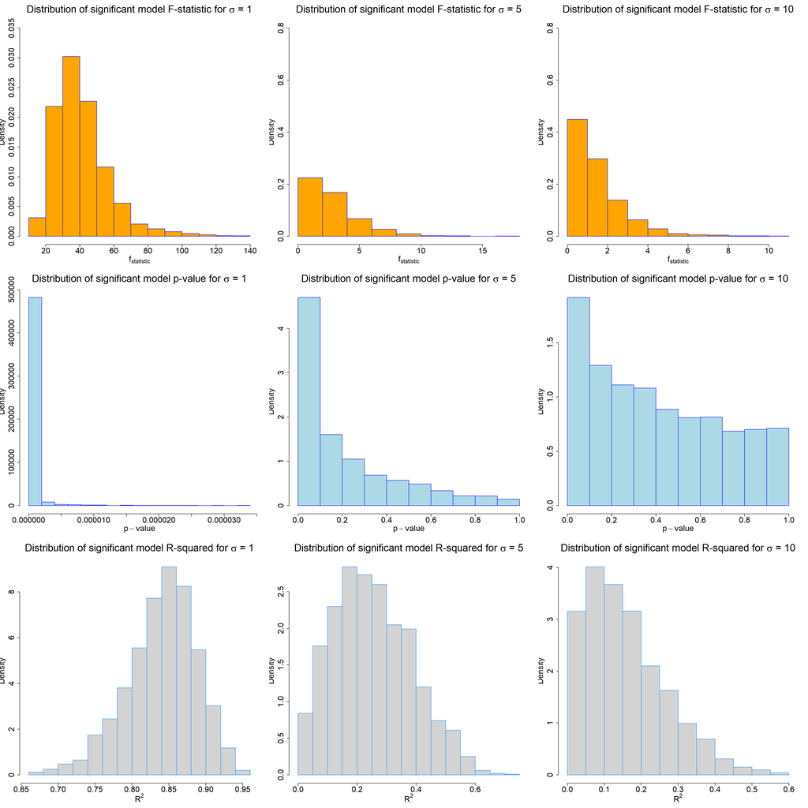

The plot show distributions of non-significant model $F$ statistic, p-value and $R^2$, along with true distribution curve on the top.

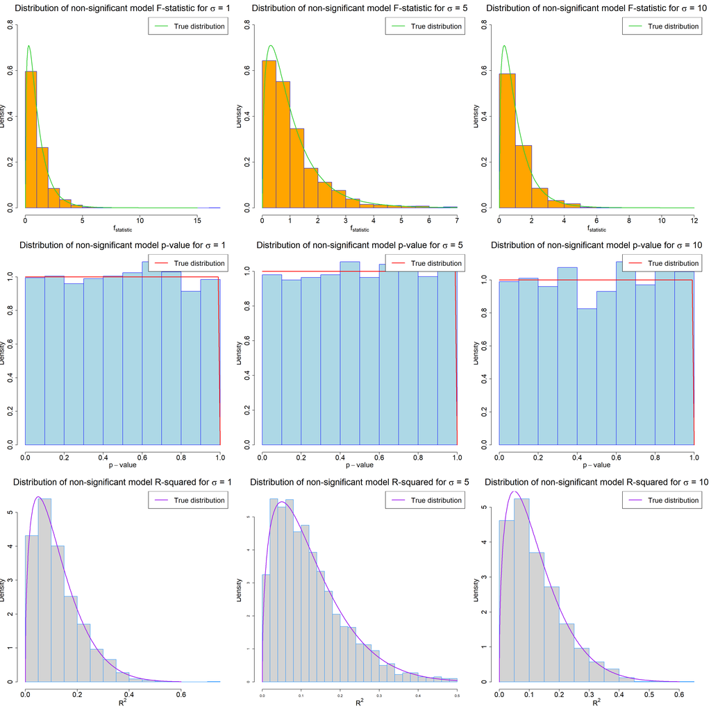

The plot show distributions of $F$ statistic, p-value and $R^2$ from both non-significant model(blue) and significant model(grey), along with true distribution curve(orange) on the top.

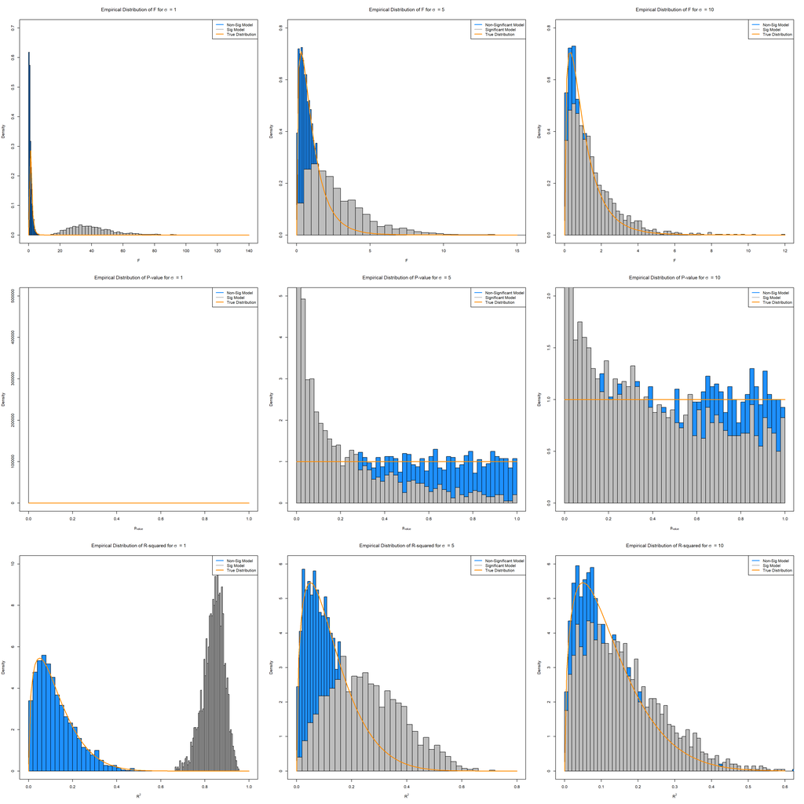

**Discussion**

- Do we know the true distribution of any of these values?

We know the true distribution of non-significant model. The non-significant model is the linear regression model under the null hypothesis.

The true distribution of $R^2$ in non-significant model, under the null hypothesis is true, is

$$R^2 \sim Beta\left (\frac {p-1}{2}, \frac {n-p}{2}\right)$$

The true distribution of $F$ statistic in non-significant model, under the null hypothesis is true, is

$$F \sim F_{p-1, n-p}$$

The true distribution of $p$-value in non-significant model, under the null hypothesis is true, is

$$p \sim Unif(0,1)$$

From researching online, We could know the true distribution of significant model.

The true distribution of $R^2$ in significant model, under the alternative hypothesis is true, is a non-central $R^2$-distribution

$$R^2 \sim Beta\left (\frac {k-1}{2}, \frac {N-k}{2}, \lambda\right)$$

The true distribution of $F$ statistic in significant model, under the alternative hypothesis is true, is a non-central $F$-distribution

$$F \sim F_{k-1, N-k, \lambda}$$
where
$$\lambda = \sum_in_i(\mu_i -
\bar\mu)^2$$
and
$$\bar\mu =
\sum_in_i\mu_i/N$$

The true distribution of $p$-value in significant model, under the alternative hypothesis is true, is

$$p \sim P( F_{k-1, N-k, \lambda} > F )$$

- How do the empirical distributions from the simulations compare to the true distributions?

We conducted simulations to generate the empirical distribution of estimates from non-significant models for different $\sigma$ values. The $F$ statistic histogram from these simulations appears to follow an F-distribution with (p - 1) = 3 degrees of freedom and (n - p) = 21 degrees of freedom. We verified this by comparing it to the curve of the true $F$ statistic, which matched for all $\sigma$ values.

Similarly, we observed that the p-values under the null are uniformly distributed between 0 and 1 for all three levels of $\sigma$. This was confirmed by comparing the empirical distribution plot to a uniform distribution.

We also calculated $R^2$ from the non-significant model during simulation and created a histogram of the empirical distribution. The curve of the true distribution, which follows a beta distribution with (p - 1) = 3 degrees of freedom and (n - p) = 21 degrees of freedom, matched the histogram for all $\sigma$ values.

Overall, our simulations demonstrate that the distributions of $F$ statistic, p-values, and $R^2$ from non-significant model are consistent with their theoretical distributions for all levels of $\sigma$.

- How are each of the $F$ statistic, the p-value, and $R^2$ related to $\sigma$? Are any of those relationships the same for the significant and non-significant models?

$F$ statistic: The $F$ statistic is calculated by

$$F = \frac{\sum_{i=1}^{n}(\hat{y}_{1i} - \bar{y})^2 / (p -
1)}{\sum_{i=1}^{n}(y_i - \hat{y}_{1i})^2 / (n - p)},$$

As $\sigma$ increases, the denomator increases, which leads to a decrease in the $F$ statistic. A small value of the $f$ statistic corresponds to a small portion of the variance being explained by the linear regression model.

$p$-value: The $p$-value is a probability that calcaulted by

$$P(F_{p-1, n-p} > F)$$

$R^2$: $R^2$ is the proportion of observed variation in $y$ that can be explained by the simple linear regression model..

$$R^2 = 1 - \frac{\sum_{i = 1}^{n}e_i^2}{\sum_{i=1}^{n}(y_i -
\bar{y})^2}$$

As $\sigma$ increases, the variability of the response variable $y$ increases, the denomator increases, which leads to a decrease in $R^2$.

In analyzing the results from both significant and non-significant models, we observe that as the noise level increases, the distribution of test statistic from the significant model becomes more sensitive to the sigma. When the noise is large, the distribution of test statistic from the significant model is closer to that of the non-significant model. We also note that under the null hypothesis, the p-values are uniformly distributed between 0 and 1, while under the alternative hypothesis, they are skewed towards small values at the left. As the noise level increases in the model, we can clearly see that the R-squared distribution under the alternative hypothesis becomes right-skewed, from left skewed.

All three test statistic distributions of significant model are closer to that of the non-significant model while the noise level increases. These observations have important implications for statistical analysis. In particular, they highlight the importance of carefully considering noise levels when interpreting results from statistical models.

# Simulation Study 2: Using RMSE for Selection?

**Introduction**

In this simulation study we will investigate how well the Test RMSE can be used to select the “best” model works. Since splitting the data is random, we don’t expect it to work correctly each time. We could get unlucky. But averaged over many attempts, we should expect it to select the appropriate model.

We will simulate from the model

$$Y_i = \beta_0 + \beta_1 x_{i1} + \beta_2 x_{i2} + \beta_3 x_{i3} +
\beta_4 x_{i4} + \beta_5 x_{i5} + \beta_6 x_{i6} + \epsilon_i$$

where $\epsilon_i \sim N(0, \sigma^2)$ and

- $\beta_0 = 0$,
- $\beta_1 = 3$,
- $\beta_2 = -4$,
- $\beta_3 = 1.6$,
- $\beta_4 = -1.1$,
- $\beta_5 = 0.7$,
- $\beta_6 = 0.5$.

We will consider a sample size of $500$ and three possible levels of noise. That is, three values of $\sigma$.

- $n = 500$
- $\sigma \in (1, 2, 4)$

We will use the data found in `study_2.csv` for the values of the predictors. These will be kept constant for the entirety of this study. The `y` values in this data are a blank placeholder.

Each time we simulate the data, we will randomly split the data into train and test sets of equal sizes (250 observations for training, 250 observations for testing).

For each, fit **nine** models, with forms:

- `y ~ x1`
- `y ~ x1 + x2`
- `y ~ x1 + x2 + x3`
- `y ~ x1 + x2 + x3 + x4`
- `y ~ x1 + x2 + x3 + x4 + x5`
- `y ~ x1 + x2 + x3 + x4 + x5 + x6`, the correct form of the model as noted above
- `y ~ x1 + x2 + x3 + x4 + x5 + x6 + x7`
- `y ~ x1 + x2 + x3 + x4 + x5 + x6 + x7 + x8`
- `y ~ x1 + x2 + x3 + x4 + x5 + x6 + x7 + x8 + x9`

For each model, calculate Train and Test RMSE.

$$\text{RMSE}(\text{model, data}) = \sqrt{\frac{1}{n} \sum_{i = 1}^{n}(y_i
- \hat{y}_i)^2}$$

We will repeat this process with $1000$ simulations for each of the $3$ values of $\sigma$. For each value of $\sigma$, we will create a plot that shows how average Train RMSE and average Test RMSE changes as a function of model size. Also we will show the number of times the model of each size was chosen for each value of $\sigma$.

We will have simulated the $y$ vector $3×1000=3000$ times. We will have fit $9×3×1000=27000$ models.

**Methods**

We simulate the $y$ vector $3×1000=3000$ times. We then fit $9×3×1000=27000$ models.

```r
#Setting the seed
birthday = 19910130
set.seed(birthday)

library(readr)
study_2 = read_csv("study_2.csv")
study_2 = subset(study_2, select = -y)
#Creating necessasary variables
beta_0 = 0
beta_1 = 3
beta_2 = -4
beta_3 = 1.6
beta_4 = -1.1
beta_5 = 0.7
beta_6 = 0.5

n = 500
p = 7
sim_size = 1000

sigma = list(1,2,4)

library(tibble)

# define data generating processs
gen_slr_data = function(x, sample_size = 500, sigma) {
  x0 = rep(1, n = sample_size)
  y = 0 * x0  + 3 * x[[1]] - 4 * x[[2]] + 1.6 * x[[3]] - 1.1 * x[[4]] + 0.7 * x[[5]] + 0.5 * x[[6]] + rnorm(n = sample_size, mean = 0, sd = sigma)
  tibble(x0, x, y)
}

# function to obtain RMSE
rmse = function(actual, predicted) {
  sqrt(mean((actual - predicted) ^ 2))
}


# function to simulate entire dataset
sim_rmse = function(x = study_2, sigma_1) {
  sim_slr_data = gen_slr_data(x, sample_size = 500, sigma = sigma_1)
  # test-train split
  slr_trn_idx = sample(nrow(sim_slr_data), size = 0.5 * nrow(sim_slr_data))
  slr_trn = sim_slr_data[slr_trn_idx, ]
  slr_tst = sim_slr_data[-slr_trn_idx, ]
  # create a list of the models fit.
  mod_list = list(
  model1 = lm(y ~ x1, data = slr_trn),
  model2 = lm(y ~ x1 + x2, data = slr_trn),
  model3 = lm(y ~ x1 + x2 + x3, data = slr_trn),
  model4 = lm(y ~ x1 + x2 + x3 + x4, data = slr_trn),
  model5 = lm(y ~ x1 + x2 + x3 + x4 + x5, data = slr_trn),
  model6 = lm(y ~ x1 + x2 + x3 + x4 + x5 + x6, data = slr_trn),
  model7 = lm(y ~ x1 + x2 + x3 + x4 + x5 + x6 + x7, data = slr_trn),
  model8 = lm(y ~ x1 + x2 + x3 + x4 + x5 + x6 + x7 + x8, data = slr_trn),
  model9 = lm(y ~ x1 + x2 + x3 + x4 + x5 + x6 + x7 + x8 + x9, data = slr_trn)
  )

  # make predictions on the train data with each model
  mod_trn_pred = lapply(mod_list, predict, slr_trn)

  # make predictions on the test data with each model
  mod_tdt_pred = lapply(mod_list, predict, slr_tst)


  list(
  # calculate train RMSE
  slr_trn_rmse = sapply(mod_trn_pred, rmse, actual = slr_trn$y),
  # calculate test RMSE
  slr_tst_rmse = sapply(mod_tdt_pred, rmse, actual = slr_tst$y)
  )

}


# perform simulation procedure for sigma value of 1,2, 4
rmses_1 = replicate(n = sim_size, sim_rmse(study_2, sigma[[1]]))
rmses_2 = replicate(n = sim_size, sim_rmse(study_2, sigma[[2]]))
rmses_4 = replicate(n = sim_size, sim_rmse(study_2, sigma[[3]]))
```

We then plot the results. The train RMSE can be seen in blue, while the test RMSE is given in orange.

```r
par(mfrow = c(1, 3)) # c(3, 1)
#Plotting RMSE's
#sigma value of 1
train_rmse_1 = do.call(rbind, rmses_1[1,]) #train RMSE
test_rmse_1 = do.call(rbind, rmses_1[2,]) #test RMSE

means_train = apply(train_rmse_1, 2, mean) # mean of train RMSE
means_test = apply(test_rmse_1, 2, mean)# mean of train RMSE

model_complexity = list(1, 2, 3, 4, 5, 6, 7, 8, 9)

plot(
  model_complexity,
  means_train,
  type = "b",
  main = expression(paste(
    "Mean of Model RMSE Vs Model Size with ", sigma, " = 1"
  )),
  xlim = c(0.50, 9.50),
  ylim = c(min(c(
    means_train, means_test
  )) - 0.02, max(c(
    means_train, means_test
  )) + 0.02),
  cex.axis = 1.5,
  cex.lab = 1.5,
  xlab = "Model Size",
  ylab = "Mean of Model RMSE",
  col = "dodgerblue",
  cex.main = 2
)
lines(model_complexity,
      means_test,
      type = "b",
      col = "darkorange")
text(
  model_complexity,
  means_train,
  labels = round(means_train, 3),
  pos = 1,
  cex = 2,
  col = "dodgerblue"
)
text(
  model_complexity,
  means_test,
  labels = round(means_test, 3),
  pos = 3,
  cex = 2,
  col = "darkorange"
)
legend(
  "topright",
  legend = c("train RMSE", "test RMSE"),
  lty = c(1, 2),
  lwd = 2,
  col = c("dodgerblue", "darkorange"),
  title = "Model RMSE",
  text.font = 4,
  cex = 2,
  pt.cex = 3
)


#sigma value of 2
train_rmse_2 = do.call(rbind, rmses_2[1,]) #train RMSE
test_rmse_2 = do.call(rbind, rmses_2[2,]) #test RMSE

means_train = apply(train_rmse_2, 2, mean) # mean of train RMSE
means_test = apply(test_rmse_2, 2, mean)

plot(
  model_complexity,
  means_train,
  type = "b",
  main = expression(paste(
    "Mean of Model RMSE Vs Model Size with ", sigma, " = 2"
  )),
  xlim = c(0.50, 9.50),
  ylim = c(min(c(
    means_train, means_test
  )) - 0.02, max(c(
    means_train, means_test
  )) + 0.02),
  cex.axis = 1.5,
  cex.lab = 1.5,
  xlab = "Model Size",
  ylab = "Mean Of Model RMSE",
  col = "dodgerblue",
  cex.main = 2
)
lines(model_complexity,
      means_test,
      type = "b",
      col = "darkorange")
text(
  model_complexity,
  means_train,
  labels = round(means_train, 3),
  pos = 1,
  cex = 2,
  col = "dodgerblue"
)
text(
  model_complexity,
  means_test,
  labels = round(means_test, 3),
  pos = 3,
  cex = 2,
  col = "darkorange"
)
legend(
  "topright",
  legend = c("train RMSE", "test RMSE"),
  lty = c(1, 2),
  lwd = 2,
  col = c("dodgerblue", "darkorange"),
  title = "Model RMSE",
  text.font = 4,
  cex = 2,
  pt.cex = 3
)

#sigma value of 4
train_rmse_4 = do.call(rbind, rmses_4[1,]) #train RMSE
test_rmse_4 = do.call(rbind, rmses_4[2,]) #test RMSE

means_train = apply(train_rmse_4, 2, mean) # mean of train RMSE
means_test = apply(test_rmse_4, 2, mean)

plot(
  model_complexity,
  means_train,
  type = "b",
  main = expression(paste(
    "Mean of Model RMSE Vs Model Size with ", sigma, " = 4"
  )),
  xlim = c(0.50, 9.50),
  ylim = c(min(c(
    means_train, means_test
  )) - 0.02, max(c(
    means_train, means_test
  )) + 0.02),
  cex.axis = 1.5,
  cex.lab = 1.5,
  xlab = "Model Size",
  ylab = "Mean of Model RMSE",
  col = "dodgerblue",
  cex.main = 2
)
lines(model_complexity,
      means_test,
      type = "b",
      col = "darkorange")
text(
  model_complexity,
  means_train,
  labels = round(means_train, 3),
  pos = 1,
  cex = 2,
  col = "dodgerblue"
)
text(
  model_complexity,
  means_test,
  labels = round(means_test, 3),
  pos = 3,
  cex = 2,
  col = "darkorange"
)
legend(
  "topright",
  legend = c("train RMSE", "test RMSE"),
  lty = c(1, 2),
  lwd = 2,
  col = c("dodgerblue", "darkorange"),
  title = "Model RMSE",
  text.font = 4,
  cex = 2,
  pt.cex = 3
)
```

We also plot the RMSE values at each level of $\sigma$. Within a single plot for a given $\sigma$, one line could correspond to the training data and the other to the test data.

```r
par(mfrow = c(1, 2))
#Plotting RMSE's
# train RMSE
model_complexity = list(1, 2, 3, 4, 5, 6, 7, 8, 9)

means_train_1 = apply(train_rmse_1, 2, mean)
means_train_2 = apply(train_rmse_2, 2, mean)
means_train_3 = apply(train_rmse_4, 2, mean)
plot(
  model_complexity,
  means_train_1,
  type = "b",
  main = expression(paste(
    "Mean of train RMSE Vs Model Size for different ", sigma, " values"
  )),
  xlim = c(0.50, 9.50),
  ylim = c(min(c(
    means_train_1, means_train_3
  )) - 0.02, max(c(
    means_train_1, means_train_3
  )) + 0.02),
  cex.axis = 1.5,
  cex.lab = 1.5,
  xlab = "Model Size",
  ylab = "Mean of train RMSE",
  col = "dodgerblue",
  cex.main = 2
)
lines(model_complexity,
      means_train_2,
      type = "b",
      col = "darkorange")
lines(model_complexity,
      means_train_3,
      type = "b",
      col = "grey")
text(
  model_complexity,
  means_train_1,
  labels = round(means_train_1, 3),
  pos = 1,
  cex = 2,
  col = "dodgerblue"
)
text(
  model_complexity,
  means_train_2,
  labels = round(means_train_2, 3),
  pos = 3,
  cex = 2,
  col = "darkorange"
)
text(
  model_complexity,
  means_train_3,
  labels = round(means_train_3, 3),
  pos = 3,
  cex = 2,
  col = "grey"
)
legend(
  "topright",
  legend = c(expression(paste(sigma, " = ", 1)),
             expression(paste(sigma, " = ", 2)),
             expression(paste(sigma, " = ", 4))),
  lty = c(1, 2),
  lwd = 2,
  col = c("dodgerblue", "darkorange", "grey"),
  title = expression(paste(sigma, " values")),
  text.font = 4,
  cex = 2,
  pt.cex = 3
)


# test RMSE
means_test_1 = apply(test_rmse_1, 2, mean)
means_test_2 = apply(test_rmse_2, 2, mean)
means_test_3 = apply(test_rmse_4, 2, mean)
plot(
  model_complexity,
  means_test_1,
  type = "b",
  main = expression(paste(
    "Mean of test RMSE Vs Model Size for different ", sigma, " values"
  )),
  xlim = c(0.50, 9.50),
  ylim = c(min(c(
    means_train_1, means_train_3
  )) - 0.02, max(c(
    means_train_1, means_train_3
  )) + 0.02),
  cex.axis = 1.5,
  cex.lab = 1.5,
  xlab = "Model Size",
  ylab = "Mean of test RMSE",
  col = "dodgerblue",
  cex.main = 2
)
lines(model_complexity,
      means_test_2,
      type = "b",
      col = "darkorange")
lines(model_complexity,
      means_test_3,
      type = "b",
      col = "grey")
text(
  model_complexity,
  means_test_1,
  labels = round(means_test_1, 3),
  pos = 1,
  cex = 2,
  col = "dodgerblue"
)
text(
  model_complexity,
  means_test_2,
  labels = round(means_test_2, 3),
  pos = 3,
  cex = 2,
  col = "darkorange"
)
text(
  model_complexity,
  means_test_3,
  labels = round(means_test_3, 3),
  pos = 3,
  cex = 2,
  col = "grey"
)
legend(
  "topright",
  legend = c(expression(paste(sigma, " = ", 1)),
             expression(paste(sigma, " = ", 2)),
             expression(paste(sigma, " = ", 4))),
  lty = c(1, 2),
  lwd = 2,
  col = c("dodgerblue", "darkorange", "grey"),
  title = expression(paste(sigma, " values")),
  text.font = 4,
  cex = 2,
  pt.cex = 3
)
```

We then plot model selection for each model size at each level of $\sigma$.

```r
#Model Selection for each value of sigma
df1 = as.data.frame(table(colnames(test_rmse_1)[apply(test_rmse_1, 1, which.min)]))
df2 = as.data.frame(table(colnames(test_rmse_2)[apply(test_rmse_2, 1, which.min)]))
df3 = as.data.frame(table(colnames(test_rmse_4)[apply(test_rmse_4, 1, which.min)]))
plot(
  as.numeric(gsub("\\D", "", df1$Var1)),
  df1$Freq, type = "b",
  main = expression(paste(
    "Model Selections vs Model Size for different ", sigma, " values"
  )),
  xlim = c(1.00, 9.50),
  cex.axis = 2,
  cex.lab = 2,
  xlab = "Model Size",
  ylab = "Model Selections",
  cex.main = 2
)
lines(as.numeric(gsub("\\D", "", df1$Var1)),
  df1$Freq, type = "b", col = "dodgerblue")
text(
  as.numeric(gsub("\\D", "", df1$Var1)),
  df1$Freq,
  labels = df1$Freq,
  pos = 2,
  cex = 2,
  col = "dodgerblue"
)


lines(as.numeric(gsub("\\D", "", df2$Var1)),
  df2$Freq, type = "b", col = "darkorange")
text(
  as.numeric(gsub("\\D", "", df2$Var1)),
  df2$Freq,
  labels = df2$Freq,
  pos = 4,
  cex = 2,
  col = "darkorange"
)


lines(as.numeric(gsub("\\D", "", df3$Var1)),
  df3$Freq, type = "b", col = "grey")
text(
  as.numeric(gsub("\\D", "", df3$Var1)),
  df3$Freq,
  labels = df3$Freq,
  pos = 1,
  cex = 2,
  col = "grey"
)
legend(
  "topright",
  legend = c(expression(paste(sigma, " = ", 1)),
             expression(paste(sigma, " = ", 2)),
             expression(paste(sigma, " = ", 4))),
  lty = c(1, 2),
  lwd = 2,
  col = c("dodgerblue", "darkorange", "grey"),
  title = expression(paste(sigma, " values")),
  text.font = 4,
  cex = 2,
  pt.cex = 3
)
```

We also plot model selection for each model size at each level of $\sigma$ seperately.

```r
#Model Selection for each value of sigma
df1 = as.data.frame(table(colnames(test_rmse_1)[apply(test_rmse_1, 1, which.min)]))
df2 = as.data.frame(table(colnames(test_rmse_2)[apply(test_rmse_2, 1, which.min)]))
df3 = as.data.frame(table(colnames(test_rmse_4)[apply(test_rmse_4, 1, which.min)]))

par(mfrow = c(1, 3))

plot(
  as.numeric(gsub("\\D", "", df1$Var1)),
  df1$Freq, type = "b",
  main = expression(paste(
    "Model Selections vs Model Size for ", sigma, " = 1"
  )),
  cex.axis = 2,
  cex.lab = 2,
  xlab = "Model Size",
  ylab = "Frequency",
  cex.main = 2
)
lines(as.numeric(gsub("\\D", "", df1$Var1)),
  df1$Freq, type = "b", col = "darkorange")
text(
  as.numeric(gsub("\\D", "", df1$Var1)),
  df1$Freq,
  labels = df1$Freq,
  pos = 3,
  cex = 2,
  col = "darkorange"
)

plot(
  as.numeric(gsub("\\D", "", df2$Var1)),
  df2$Freq, type = "b",
  main = expression(paste(
    "Model Selections vs Model Size for ", sigma, " = 2"
  )),
  cex.axis = 2,
  cex.lab = 2,
  xlab = "Model Size",
  ylab = "Frequency",
  cex.main = 2
)
lines(as.numeric(gsub("\\D", "", df2$Var1)),
  df2$Freq, type = "b", col = "darkorange")
text(
  as.numeric(gsub("\\D", "", df2$Var1)),
  df2$Freq,
  labels = df2$Freq,
  pos = 3,
  cex = 2,
  col = "darkorange"
)


plot(
  as.numeric(gsub("\\D", "", df3$Var1)),
  df3$Freq, type = "b",
  main = expression(paste(
    "Model Selections vs Model Size for ", sigma, " = 4"
  )),
  cex.axis = 2,
  cex.lab = 2,
  xlab = "Model Size",
  ylab = "Frequency",
  cex.main = 2
)
lines(as.numeric(gsub("\\D", "", df3$Var1)),
  df3$Freq, type = "b", col = "darkorange")
text(
  as.numeric(gsub("\\D", "", df3$Var1)),
  df3$Freq,
  labels = df3$Freq,
  pos = 3,
  cex = 2,
  col = "darkorange"
)
```

**Results**

The plot show the difference between average of Model train and test RMSE with each $\sigma$ level

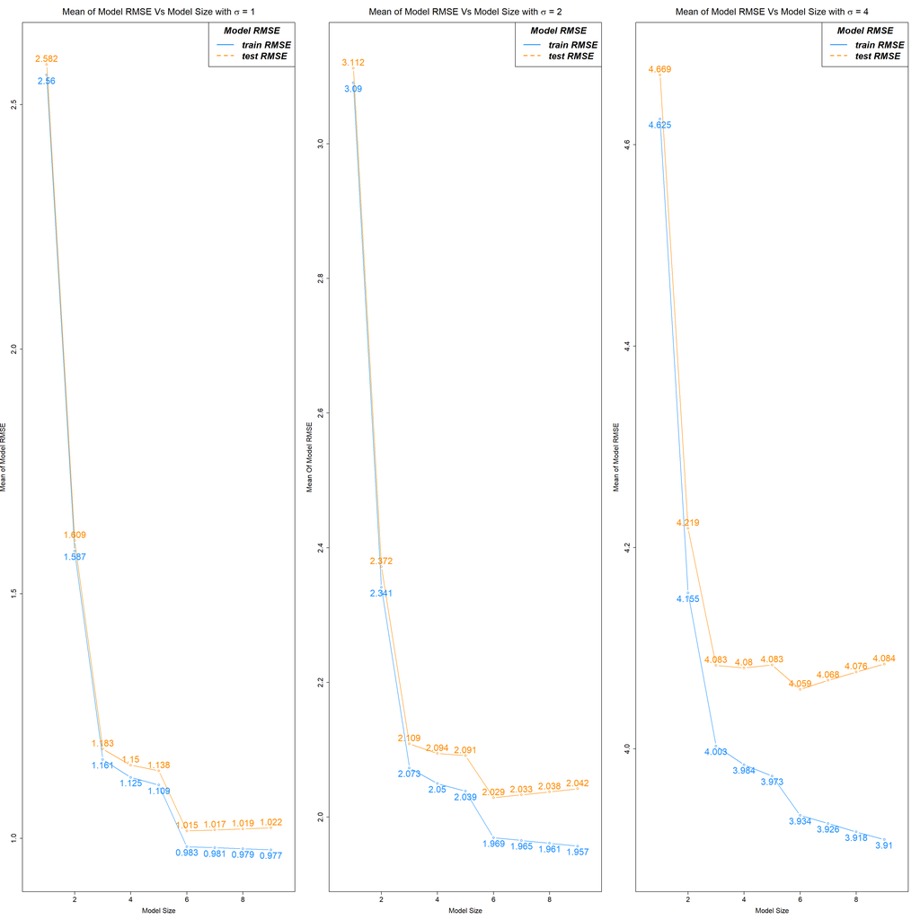

The plot show the difference of RMSE between each $\sigma$ level, left is average model train RMSE, right is average model test RMSE

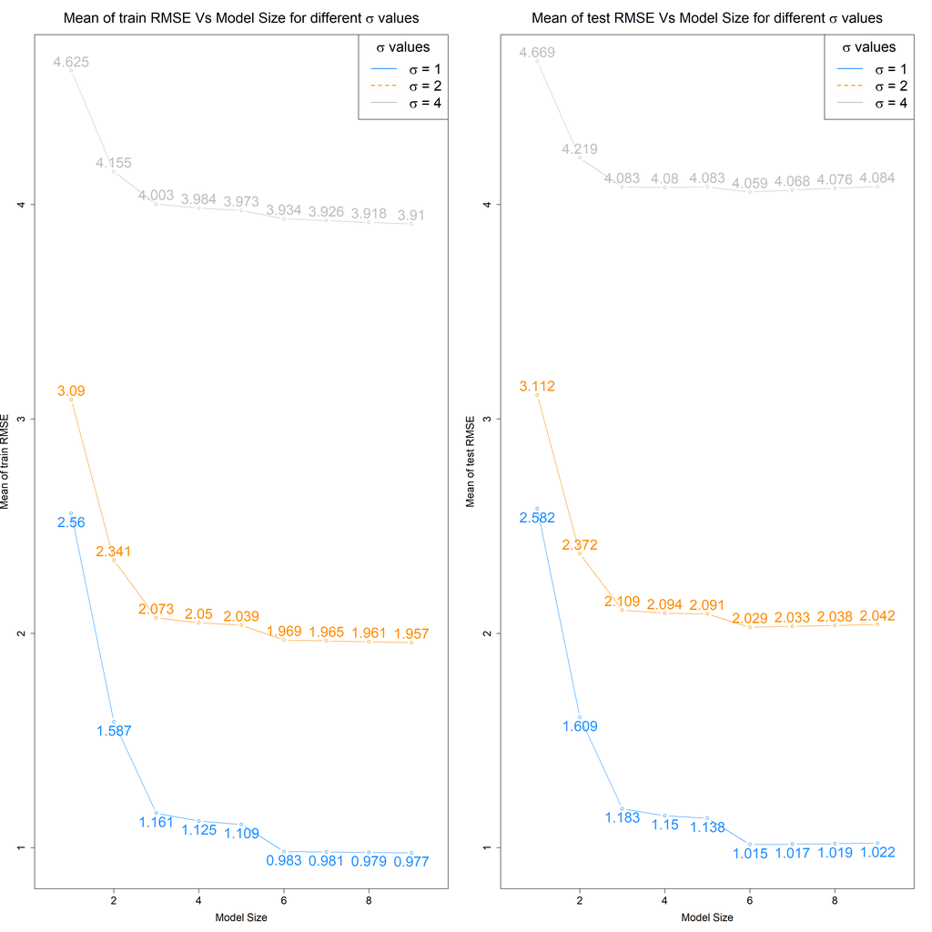

The plot show the difference of model selection between each $\sigma$ level

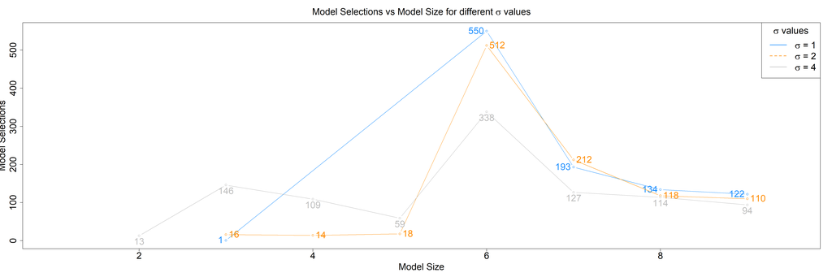

The plot show the model selection between each $\sigma$ level seperately

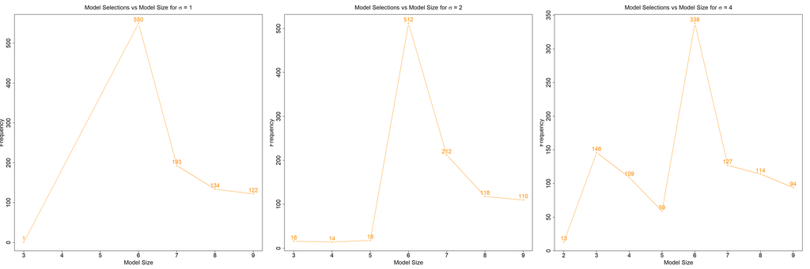

**Discussion**

- Does the method **always** select the correct model? On average, does is select the correct model?

The method **does not always** select the correct model. On average, It does select the correct model.

The model selection plots above provide insight into which model was chosen as the best model and how many times. It is clear from these plots that the true model (model 6) was chosen more frequently than any other model, with 550, 512, and 338 selections for $\sigma$ values of 1, 2, and 4 respectively. While the true model was the most commonly selected model overall, it is important to note that the simulations do not always choose the true model as the correct one.

Looking at the average test RMSE plots, which are generated from unseen data, we can see that the lowest average test RMSE for every $\sigma$ value is associated with the true model (model 6). This suggests that, on average, our simulation process is able to identify the given true model as the best model.

Overall, these plots indicate that while the simulations may not always select the true model, on average, it does select the correct model.

- How does the level of noise affect the results?

The impact of noise on model accuracy is further illustrated in the model selection plots. As the level of noise increases, there is a greater chance that other models will be selected as the “correct” model, even though they may not accurately capture the true underlying relationship between the predictors and response. This means that there is less chance that the true model will be selected as the correct model when there is more noise present in the data.

In summary, as the level of noise increases, the model’s ability to accurately capture the underlying relationship between the predictors and the response decreases, which leads to an increase in the model’s RMSE.

# Simulation Study 3: Power

**Introduction**

In this simulation study we will investigate the **power** of the significance of regression test for simple linear regression.

$$H_0: \beta_{1} = 0 \ \text{vs} \ H_1: \beta_{1} \neq 0$$

Recall, we had defined the *significance* level, $\alpha$, to be the probability of a Type I error.

$$\alpha = P[\text{Reject } H_0 \mid H_0 \text{ True}] = P[\text{Type I
Error}]$$

Similarly, the probability of a Type II error is often denoted using $\beta$; however, this should not be confused with a regression parameter.

$$\beta = P[\text{Fail to Reject } H_0 \mid H_1 \text{ True}] =
P[\text{Type II Error}]$$

*Power* is the probability of rejecting the null hypothesis when the null is not true, that is, the alternative is true and $\beta_{1}$ is non-zero.

$$\text{Power} = 1 - \beta = P[\text{Reject } H_0 \mid H_1 \text{ True}]$$

Essentially, power is the probability that a signal of a particular strength will be detected. Many things affect the power of a test. In this case, some of those are:

- Sample Size, $n$
- Signal Strength, $\beta_1$
- Noise Level, $\sigma$
- Significance Level, $\alpha$

We’ll investigate the first three.

To do so we will simulate from the model

$$Y_i = \beta_0 + \beta_1 x_i + \epsilon_i$$

where $\epsilon_i \sim N(0, \sigma^2)$.

For simplicity, we will let $\beta_0 = 0$, thus $\beta_1$ is essentially controlling the amount of “signal.” We will then consider different signals, noises, and sample sizes:

- $\beta_1 \in (-2, -1.9, -1.8, \ldots, -0.1, 0, 0.1, 0.2, 0.3, \ldots 1.9, 2)$
- $\sigma \in (1, 2, 4)$
- $n \in (10, 20, 30)$

We will hold the significance level constant at $\alpha = 0.05$.

Use the following code to generate the predictor values, `x`: values for different sample sizes.

```r
x_values = seq(0, 5, length = n)
```

For each possible $\beta_1$ and $\sigma$ combination, we will simulate from the true model at least $1000$ times. Each time, we would perform the significance of the regression test.

It is *possible* to derive an expression for power mathematically, but often this is difficult, so instead, we rely on simulation.

**Methods**

For each possible $\beta_1$ and $\sigma$ combination, we simulate from the true model $1000$ times. Each time, we perform the significance of the regression test and store the results.

```r
library(dplyr)
#Setting the seed
birthday = 19910130
set.seed(birthday)

#set up parameters
sigmas = c(1, 2, 4)
n = list(10, 20, 30)
beta_0 = 0
beta_1s = seq(-2,2,by=0.1)
num_sims = 1000
alpha = 0.05

# function to generate x values
gen_x = function(n = 10) {
  seq(0, 5, length = n)
}

# create a list to store x_value for each sample size
x_value_lists = sapply(n, gen_x)

# generate different sigma and beta1 variable combinations for the function gen_mod
g = do.call(cbind, expand.grid( sigmas, beta_1s) )
colnames(g) = c("sigma", "beta_1")
sim_g = g[rep(seq_len(nrow(g)), each = num_sims), ]

# function to generate model lists from different sigma and beta1 combinations
gen_mod = function(sample_size, sigma, beta_1) {
  x = x_value_lists[[sample_size / 10]]
  y = beta_0 + beta_1 * x + rnorm(sample_size,mean=0,sd = sigma)
  model = lm(y ~ x)
  summary(model)$coefficients[2, ]
}

# perform simulation procedure for sigma value of 1
sim_mod_list = mapply(gen_mod, n[[1]], sim_g[, 1], sim_g[, 2])

result = do.call(rbind, lapply(seq_len(ncol(sim_mod_list )), function(i) sim_mod_list [,i]))

result = cbind(sample_size = rep(n[[1]], nrow(sim_g)), sim_g, result, power = result[, 4] < alpha)
# perform simulation procedure for sigma value of 2
sim_mod_list_2 = mapply(gen_mod, n[[2]], sim_g[, 1], sim_g[, 2])

result_2 = do.call(rbind, lapply(seq_len(ncol(sim_mod_list_2)), function(i) sim_mod_list_2[,i]))

result_2 = cbind(sample_size = rep(n[[2]], nrow(sim_g)), sim_g, result_2, power = result_2[, 4] < alpha)
# perform simulation procedure for sigma value of 4
sim_mod_list_3 = mapply(gen_mod, n[[3]], sim_g[, 1], sim_g[, 2])

result_3 = do.call(rbind, lapply(seq_len(ncol(sim_mod_list_3)), function(i) sim_mod_list_3[,i]))

result_3 = cbind(sample_size = rep(n[[3]], nrow(sim_g)), sim_g, result_3, power = result_3[, 4] < alpha)

results = rbind(result, result_2, result_3)

# store result for different plot

sig1 = as.data.frame(result) %>%
  group_by(sigma, beta_1) %>%
  summarise_at(vars(power), mean)

sig2 = as.data.frame(result_2) %>%
  group_by(sigma, beta_1) %>%
  summarise_at(vars(power), mean)

sig3 = as.data.frame(result_3) %>%
  group_by(sigma, beta_1) %>%
  summarise_at(vars(power), mean)

# store result for different plot

result = as.data.frame(result)
result_2 = as.data.frame(result_2)
result_3 = as.data.frame(result_3)
beta_0 = 0
beta_1 = -2
sigma_1 = 1
sigma_2 = 2
sigma_4 = 4

Sxx_10 = sum((x_value_lists[[1]] - mean(x_value_lists[[1]])) ^ 2)

beta_1_hats_10_1 = result[result$sample_size == 10 & result$sigma == 1 & result$beta_1 == -2, ]$Estimate

beta_1_hats_10_2 = result[result$sample_size == 10 & result$sigma == 2 & result$beta_1 == -2, ]$Estimate

beta_1_hats_10_4 = result[result$sample_size == 10 & result$sigma == 4 & result$beta_1 == -2, ]$Estimate

Sxx_20 = sum((x_value_lists[[2]] - mean(x_value_lists[[2]])) ^ 2)

beta_1_hats_20_1 = result_2[result_2$sample_size == 20 & result_2$sigma == 1 & result_2$beta_1 == -2, ]$Estimate

beta_1_hats_20_2 = result_2[result_2$sample_size == 20 & result_2$sigma == 2 & result_2$beta_1 == -2, ]$Estimate

beta_1_hats_20_4 = result_2[result_2$sample_size == 20 & result_2$sigma == 4 & result_2$beta_1 == -2, ]$Estimate

Sxx_30 = sum((x_value_lists[[3]] - mean(x_value_lists[[3]])) ^ 2)

beta_1_hats_30_1 = result_3[result_3$sample_size == 30 & result_3$sigma == 1 & result_3$beta_1 == -2, ]$Estimate

beta_1_hats_30_2 = result_3[result_3$sample_size == 30 & result_3$sigma == 2 & result_3$beta_1 == -2, ]$Estimate

beta_1_hats_30_4 = result_3[result_3$sample_size == 30 & result_3$sigma == 4 & result_3$beta_1 == -2, ]$Estimate


beta_1_hats_10_non = result[result$sample_size == 10 & result$sigma == 1 & result$beta_1 == 0 , ]$Estimate

beta_1_hats_10_alt = result[result$sample_size == 10 & result$sigma == 1 & round(result$beta_1, 1)==0.5, ]$Estimate

beta_1_hats_10_alt2 = result[result$sample_size == 10 & result$sigma == 1 & result$beta_1 ==1, ]$Estimate
```

```r
par(mfrow = c(1, 3))
plot(
  beta_1s,
  sig1[sig1$sigma == 1,]$power,
  xlim = range(beta_1s),
  ylim = range(0.00, 1.00),
  ylab = "Power",
  xlab = expression(beta[1]),
  main = expression(paste("Power Vs ", beta[1], " for ", sigma, " = 1 with different sample size")),
  cex.axis = 1.5,
  cex.lab = 1.5
)

#"Power Vs Signal Strength (Beta) for Sigma = 1"
lines(
  beta_1s,
  sig1[sig1$sigma == 1,]$power,
  type = "b",
  lty = 1,
  col = "grey"
)
lines(
  beta_1s,
  sig2[sig2$sigma == 1,]$power,
  type = "b",
  lty = 2,
  col = "darkorange"
)
lines(
  beta_1s,
  sig3[sig3$sigma == 1,]$power,
  type = "b",
  lty = 3,
  col = "dodgerblue"
)
legend(
  "bottomright",
  title = "sample sizes (n)",
  lty = c(3, 2, 1),
  legend = c("n = 10", "n = 20", "n = 30"),
  col = c("grey", "darkorange", "dodgerblue")
)

plot(
  beta_1s,
  sig1[sig1$sigma == 2,]$power,
  xlim = range(beta_1s),
  ylim = range(0.00, 1.00),
  ylab = "Power",
  xlab = expression(beta[1]),
  main = expression(paste("Power Vs ", beta[1], " for ", sigma, " = 2 with different sample size")),
  cex.axis = 1.5,
  cex.lab = 1.5
)
lines(
  beta_1s,
  sig1[sig1$sigma == 2,]$power,
  type = "b",
  lty = 1,
  col = "grey"
)
lines(
  beta_1s,
  sig2[sig2$sigma == 2,]$power,
  type = "b",
  lty = 2,
  col = "darkorange"
)
lines(
  beta_1s,
  sig3[sig3$sigma == 2,]$power,
  type = "b",
  lty = 3,
  col = "dodgerblue"
)
legend(
  "bottomright",
  title = "sample sizes (n)",
  lty = c(3, 2, 1),
  legend = c("n = 10", "n = 20", "n = 30"),
  col = c("grey", "darkorange", "dodgerblue")
)

plot(
  beta_1s,
  sig1[sig1$sigma == 4,]$power,
  xlim = range(beta_1s),
  ylim = range(0.00, 1.00),
  ylab = "Power",
  xlab = expression(beta[1]),
  main = expression(paste("Power Vs ", beta[1], " for ", sigma, " = 4 with different sample size")),
  cex.axis = 1.5,
  cex.lab = 1.5
)
lines(
  beta_1s,
  sig1[sig1$sigma == 4,]$power,
  type = "b",
  lty = 1,
  col = "grey"
)
lines(
  beta_1s,
  sig2[sig2$sigma == 4,]$power,
  type = "b",
  lty = 2,
  col = "darkorange"
)
lines(
  beta_1s,
  sig3[sig3$sigma == 4,]$power,
  type = "b",
  lty = 3,
  col = "dodgerblue"
)
legend(
  "bottomright",
  title = "sample sizes (n)",
  lty = c(3, 2, 1),
  legend = c("n = 10", "n = 20", "n = 30"),
  col = c("grey", "darkorange", "dodgerblue")
)

mtext('Figure 1 - Statistical Power Influenced by Different Sample Size', line = 1, outer = TRUE)
```

```r
par(mfrow = c(1, 3))
plot(
  beta_1s,
  sig1[sig1$sigma == 1,]$power,
  xlim = range(beta_1s),
  ylim = range(0.00, 1.00),
  ylab = "Power",
  xlab = expression(beta[1]),
  main = expression(paste("Power Vs ", beta[1], " for Sample size n = 10 with different ", sigma)),
  cex.axis = 1.5,
  cex.lab = 1.5
)

#"Power Vs Signal Strength (Beta) for Sample_size = 10"
lines(
  beta_1s,
  sig1[sig1$sigma == 1,]$power,
  type = "b",
  lty = 1,
  col = "grey"
)
lines(
  beta_1s,
  sig1[sig1$sigma == 2,]$power,
  type = "b",
  lty = 2,
  col = "darkorange"
)
lines(
  beta_1s,
  sig1[sig1$sigma == 4,]$power,
  type = "b",
  lty = 3,
  col = "dodgerblue"
)
legend(
  "bottomright",
  legend = c(expression(paste(sigma, " = ", 1)),
             expression(paste(sigma, " = ", 2)),
             expression(paste(sigma, " = ", 4))),
  lty = c(3, 2, 1),
  col = c("grey", "darkorange", "dodgerblue"),
  title = expression(paste(sigma, " values")),
)

plot(
  beta_1s,
  sig2[sig2$sigma == 1,]$power,
  xlim = range(beta_1s),
  ylim = range(0.00, 1.00),
  ylab = "Power",
  xlab = expression(beta[1]),
   main = expression(paste("Power Vs ", beta[1], " for Sample size n = 20 with different ", sigma)),
  cex.axis = 1.5,
  cex.lab = 1.5
)
lines(
  beta_1s,
  sig2[sig2$sigma == 1,]$power,
  type = "b",
  lty = 1,
  col = "grey"
)
lines(
  beta_1s,
  sig2[sig2$sigma == 2,]$power,
  type = "b",
  lty = 2,
  col = "darkorange"
)
lines(
  beta_1s,
  sig2[sig2$sigma == 4,]$power,
  type = "b",
  lty = 3,
  col = "dodgerblue"
)
legend(
  "bottomright",
  legend = c(expression(paste(sigma, " = ", 1)),
             expression(paste(sigma, " = ", 2)),
             expression(paste(sigma, " = ", 4))),
  lty = c(3, 2, 1),
  col = c("grey", "darkorange", "dodgerblue"),
  title = expression(paste(sigma, " values")),
)

plot(
  beta_1s,
  sig3[sig3$sigma == 1,]$power,
  xlim = range(beta_1s),
  ylim = range(0.00, 1.00),
  ylab = "Power",
  xlab = expression(beta[1]),
   main = expression(paste("Power Vs ", beta[1], " for Sample size n = 30 with different ", sigma)),
  cex.axis = 1.5,
  cex.lab = 1.5
)
lines(
  beta_1s,
  sig3[sig3$sigma == 1,]$power,
  type = "b",
  lty = 1,
  col = "grey"
)
lines(
  beta_1s,
  sig3[sig3$sigma == 2,]$power,
  type = "b",
  lty = 2,
  col = "darkorange"
)
lines(
  beta_1s,
  sig3[sig3$sigma == 4,]$power,
  type = "b",
  lty = 3,
  col = "dodgerblue"
)
legend(
  "bottomright",
  legend = c(expression(paste(sigma, " = ", 1)),
             expression(paste(sigma, " = ", 2)),
             expression(paste(sigma, " = ", 4))),
  lty = c(3, 2, 1),
  col = c("grey", "darkorange", "dodgerblue"),
  title = expression(paste(sigma, " values")),
)

mtext('Figure 2 - Statistical Power Influenced by Different Sigma', line = 1, outer = TRUE)
```

Under Null hypothesis, $\beta_1 = 0$, we plot the $\beta_1$ distribution and the therotical normal curve. We then plot the histogram and therotical distribution of $\hat\beta_1$ under the Alternative hypothesis, with two value( $\hat\beta_1 = 0.5$ and $\hat\beta_1 = 1$) just for comparsion later. The red vertical lines are the critical value for $\alpha=0.05$.

```r
alpha = 0.05
z_crit = qnorm(1- (alpha/2), mean = 0, sd = sqrt(sigma_1 ^ 2 / Sxx_10))

par(oma = c(0, 0, 3, 0))

hist(beta_1_hats_10_non, prob = TRUE, breaks = 20,
xlab = expression(hat(beta)[1]), main = expression(sigma ~ '= 1, n = 10'),col = rgb(255,192,203, max = 255, alpha = 80, names = "lt.pink"), xlim = c(-1, 2), ylim = c(0, 2.5))
curve(dnorm(x, mean = 0, sd = sqrt(sigma_1 ^ 2 / Sxx_10)),
col = "pink", add = TRUE, lwd = 3)
abline(v = z_crit, col = "red")
abline(v = -z_crit, col = "red")

hist(beta_1_hats_10_alt, prob = TRUE, breaks = 20,
xlab = expression(hat(beta)[1]),col = rgb(173,216,230,max = 255, alpha = 80, names = "lt.blue"), border = "lightskyblue", add = TRUE)
curve(dnorm(x, mean = 0.5, sd = sqrt(sigma_1 ^ 2 / Sxx_10)),
col = "lightskyblue", add = TRUE, lwd = 3)

hist(beta_1_hats_10_alt2, prob = TRUE, breaks = 20,
xlab = expression(hat(beta)[1]),col = rgb(144,238,144,max = 255, alpha = 80, names = "lt.green"),  border = "lightgreen", add = TRUE)
curve(dnorm(x, mean = 1, sd = sqrt(sigma_1 ^ 2 / Sxx_10)),
col = "lightgreen", add = TRUE, lwd = 3)


legend("topright", legend = c(expression(beta[1]~" = 0"), expression(beta[1]~" = 0.5"), expression(beta[1]~" = 1")), text.col=c("pink", "lightskyblue", "lightgreen"), bty = 'n', cex = 1.5)
mtext(expression('Figure 3 - Comparing Distributions of the different' ~hat(beta[1]) ~' Values '), line = 1, outer = TRUE)
```

In order to find how exactly each parameter affects the statistical power. For all signal strength, we set sample size of 10 and $\sigma$ of 1 here. We then can compare three different $\beta_1$ values: 0, 0.5 and 1. We plot their histogram, theoretical distribution of the t-values, and compare that with the Null hypothesis distribution. We shade the area of each curve to indicates power. On the right side, we plot the corresponding points on the power curve of this specific set of parameters.

```r
# How does beta_1 affect power?
# set up parameters

beta_1_small = 0.5
beta_1_large = 1

n = 10
ncp_small = beta_1_small/sqrt(sigma_1 ^ 2 / Sxx_10)
ncp_large = beta_1_large/sqrt(sigma_1 ^ 2 / Sxx_10)
alpha = 0.05
crit = abs(qt(alpha/2,df = n - 2))

# get the t values from the simulation
beta1_t_10_alt = result[result$sample_size == 10 & result$sigma == 1 & round(result$beta_1, 1)==0.5, ]$`t value`

beta1_t_10_lrg = result[result$sample_size == 10 & result$sigma == 1 & result$beta_1 ==1, ]$`t value`


par(oma = c(0, 0, 3, 0))
layout(matrix(c(1, 1, 2), nrow = 1, ncol = 3, byrow = TRUE))

# left: show t value distributions
hist(beta1_t_10_alt, probability = TRUE, breaks = 30, xlab = "t values", main = "", col = rgb(144,238,144,max = 255, alpha = 80, names = "lt.green"), border = "lightgreen", xlim = c(-5, 10), ylim = c(0, 0.4))

curve(dt(x, df = n - 2, ncp = ncp_small), type = "l",  add = TRUE, col = "lightgreen", lwd = 2)

prob = seq(from = crit, to = 10, by = 0.01)
polygon(c(crit, prob, 10),
          c(0, dt(prob, df = n - 2, ncp = ncp_small), 0),
           col = "lightgreen", border = NA)

hist(beta1_t_10_lrg, probability = TRUE, breaks = 50, col = rgb(173,216,230,max = 255, alpha = 80, names = "lt.blue"), border = "lightskyblue", xlim = c(-5, 11), ylim = c(0, 0.4), add = TRUE)
curve(dt(x, df = n - 2, ncp = ncp_large), type = "l",  add = TRUE, col = "lightskyblue", lwd = 2)
prob = seq(from = crit, to = 11, by = 0.01)
polygon(c(crit, prob, 11),
          c(0, dt(prob, df = n - 2, ncp = ncp_large), 0),
           col = "lightskyblue", border = NA)
curve(dt(x, df = n - 2, ncp = 0), type = "l",  add = TRUE, col = "pink", lwd = 2)
abline(v = crit, col = "red")
legend("topleft", legend = c(expression(beta[1]~" = 0"), expression(beta[1]~" = 0.5"), expression(beta[1]~" = 1")), text.col=c("red", "green3", "dodgerblue"), bty = 'n', cex = 1.5)



# right: show power curves
plot(beta_1s, sig1[sig1$sigma == 1,]$power, type = "l", main = expression('N = 10, ' ~sigma ~ '= 1'),
     xlab = expression(beta[1]), ylab = "Power", lty = 2, lwd = 1.5, ylim = c(0, 1))
points(x = beta_1_small, y = sig1[sig1$sigma == 1 & round(sig1$beta_1, 1) == 0.5,]$power, pch = 19, col = 'green')
abline(v = beta_1_small, col = "green")
points(x = beta_1_large, y = sig1[sig1$sigma == 1 & round(sig1$beta_1, 1) == 1,]$power, pch = 19, col = 'dodgerblue')
abline(v = beta_1_large, col = "dodgerblue")
points(x = 0, y = sig1[sig1$sigma == 1 & sig1$beta_1 == 0,]$power, pch = 19, col = 'red')
abline(v = 0, col = "red")

mtext('Figure 4 - Influence of Signal Strength on Power', line = 1, outer = TRUE)
```

```r
# How does sample size affect power?
# set up parameters


size_small = 10
size_large = 20
sigma_2 = 2
beta_1 = 1


sd_beta_1_small_size = sigma_2/sqrt(Sxx_10)
ncp_small_size = beta_1/sd_beta_1_small_size

sd_beta_1_large_size = sigma_2/sqrt(Sxx_20)
ncp_large_size = beta_1/sd_beta_1_large_size

alpha = 0.05
crit_small_size = abs(qt(alpha/2,df = size_small - 2))
crit_large_size = abs(qt(alpha/2,df = size_large - 2))

# get the t values from the simulation
beta1_t_10_1 = result[result$sample_size == 10 & result$sigma == 2 & result$beta_1 == 1, ]$`t value`

beta1_t_20_1 = result_2[result_2$sample_size == 20 & result_2$sigma == 2 & result_2$beta_1 == 1, ]$`t value`

par(oma = c(0, 0, 3, 0))
layout(matrix(c(1, 1, 2), nrow = 1, ncol = 3, byrow = TRUE))

# left: show t value distributions
hist(beta1_t_10_1, probability = TRUE, breaks = 30, xlab = "t values", main = "",col = rgb(144,238,144,max = 255, alpha = 80, names = "lt.green"), border = "lightgreen", xlim = c(-5, 8), ylim = c(0, 0.4))

curve(dt(x, df = size_small - 2, ncp = ncp_small_size), type = "l",  add = TRUE, col = "lightgreen", lwd = 2)

prob = seq(from = crit_small_size, to = 10, by = 0.01)
polygon(c(crit_small_size, prob, 10),
          c(0, dt(prob, df = size_small - 2, ncp = ncp_small_size), 0),
           col = "lightgreen", border = NA)

hist(beta1_t_20_1, probability = TRUE, breaks = 30, col = rgb(173,216,230,max = 255, alpha = 80, names = "lt.blue"), border = "lightskyblue", xlim = c(-5, 8), ylim = c(0, 0.4), add = TRUE)

curve(dt(x, df = size_large - 2, ncp = ncp_large_size), type = "l",  add = TRUE, col = "lightskyblue", lwd = 2)

prob = seq(from = crit_large_size, to = 10, by = 0.01)
polygon(c(crit_large_size, prob, 10),
          c(0, dt(prob, df = size_large - 2, ncp = ncp_large_size), 0),
           col = "lightskyblue", border = NA)

curve(dt(x, df = size_small - 2, ncp = 0), type = "l", add = TRUE, col = "red", lwd = 2)

#abline(h = 0)
curve(dt(x, df = size_large - 2, ncp = 0), type = "l", add = TRUE, col = "slateblue", lwd = 2)

abline(v = crit_small_size, col = "red")
abline(v = crit_large_size, col = "slateblue")

legend("topright", legend=c('N = 10','N = 20'), text.col=c("green3", "dodgerblue"), bty = 'n', cex = 1.5)

# right: show power curves
# beta_1s, sig1[sig1$sigma == 1,]$power,
plot(beta_1s, sig1[sig1$sigma == 2,]$power, type = "l", main = expression(sigma ~ '= 2, '~beta[1]~" = 1"),
     xlab = expression(beta[1]), ylab = "Power", lty = 2, lwd = 1.5, ylim = c(0, 1), col = 'green')
lines(beta_1s, sig2[sig2$sigma == 2,]$power, type = "l",
     xlab = expression(beta[1]), ylab = "Power", lty = 2, lwd = 1.5, ylim = c(0, 1), col = 'dodgerblue')
points(x = beta_1, y = sig1[sig1$sigma == 2 & sig1$beta_1 == 1,]$power, pch = 19, col = 'green')
points(x = beta_1, y = sig2[sig2$sigma == 2 & sig2$beta_1 == 1,]$power, pch = 19, col = 'dodgerblue')
abline(v = beta_1, col = "grey")

mtext('Figure 5 - Influence of Sample Size on Power', line = 1, outer = TRUE)
```

```r
# How does sigma affect power?
# set up parameters


size = 30
sigma_2 = 2
sigma_4 = 4
beta_1 = 1


sd_beta_1_small_sigma = sigma_2/sqrt(Sxx_30)
ncp_small_sigma = beta_1/sd_beta_1_small_sigma
sd_beta_1_large_sigma = sigma_4/sqrt(Sxx_30)
ncp_large_sigma = beta_1/sd_beta_1_large_sigma

alpha = 0.05
crit = abs(qt(alpha/2,df = size - 2))

# get the t values from the simulation
beta1_t_30_2 = result_3[result_3$sample_size == 30 & result_3$sigma == 2 & result_3$beta_1 == 1, ]$`t value`

beta1_t_30_4 = result_3[result_3$sample_size == 30 & result_3$sigma == 4 & result_3$beta_1 == 1, ]$`t value`


par(oma = c(0, 0, 3, 0))
layout(matrix(c(1, 1, 2), nrow = 1, ncol = 3, byrow = TRUE))

# left: show t value distributions
hist(beta1_t_30_2, probability = TRUE, breaks = 30, xlab = "t values", main = "", col = rgb(173,216,230,max = 255, alpha = 80, names = "lt.blue"), border = "lightskyblue", xlim = c(-5, 8), ylim = c(0, 0.4))

curve(dt(x, df = size - 2, ncp = ncp_small_sigma), type = "l",  add = TRUE, col = "lightskyblue", lwd = 2)

prob = seq(from = crit, to = 10, by = 0.01)
polygon(c(crit, prob, 10),
          c(0, dt(prob, df = size - 2, ncp = ncp_small_sigma), 0),
           col = "lightskyblue", border = NA)

hist(beta1_t_30_4, probability = TRUE, breaks = 30, col = rgb(144,238,144,max = 255, alpha = 80, names = "lt.green"), border = "lightgreen", xlim = c(-5, 8), ylim = c(0, 0.4), add = TRUE)

curve(dt(x, df = size - 2, ncp = ncp_large_sigma), type = "l",  add = TRUE, col = "lightgreen", lwd = 2)

prob = seq(from = crit, to = 10, by = 0.01)
polygon(c(crit, prob, 10),
          c(0, dt(prob, df = size - 2, ncp = ncp_large_sigma), 0),
          col = "lightgreen", border = NA)

curve(dt(x, df = size - 2, ncp = 0), type = "l", add = TRUE, col = "red", lwd = 2)
abline(v = crit, col = "red")
legend("topright", legend = c(expression(sigma~" = 2"), expression(sigma~" = 4")), text.col=c("dodgerblue", "green3"), bty = 'n', cex = 1.5)

# right: show power curves
plot(beta_1s, sig3[sig3$sigma == 2,]$power, type = "l", main = expression('N = 30, '~beta[1]~" = 1"),
     xlab = expression(beta[1]), ylab = "Power", lty = 2, lwd = 1.5, ylim = c(0, 1), col = 'dodgerblue')
lines(beta_1s, sig3[sig3$sigma == 4,]$power, type = "l",
     xlab = expression(beta[1]), ylab = "Power", lty = 2, lwd = 1.5, ylim = c(0, 1), col = 'green')
points(x = beta_1, y = sig3[sig3$sigma == 2 & sig3$beta_1 == 1,]$power, pch = 19, col = 'dodgerblue')
points(x = beta_1, y = sig3[sig3$sigma == 4 & sig3$beta_1 == 1,]$power, pch = 19, col = 'green')
abline(v = beta_1, col = "grey")

mtext('Figure 6 - Influence of Noise Level on Power', line = 1, outer = TRUE)
```

In order to verify the empirical distribution true means and variances and whether the distribution is normal. We plot a histogram of the $\hat\beta_1$, and add the curve for the true distribution of $\beta_1$.

```r
beta_1 = -2
layout(matrix(c(1,2,3,4,5,6,7,8,9), byrow=TRUE, ncol=3,nrow=3))

par(mar = c(5, 5, 1, 1))
hist(beta_1_hats_10_1, prob = TRUE, breaks = 20,
xlab = expression(hat(beta)[1]), main = expression(sigma ~ '= 1, n = 10'), border = "dodgerblue")
curve(dnorm(x, mean = beta_1, sd = sqrt(sigma_1 ^ 2 / Sxx_10)),
col = "darkorange", add = TRUE, lwd = 3)

par(mar = c(5, 5, 1, 1))
hist(beta_1_hats_10_2, prob = TRUE, breaks = 20,
xlab = expression(hat(beta)[1]), main = expression(sigma ~ '= 2, n = 10'), border = "dodgerblue")
curve(dnorm(x, mean = beta_1, sd = sqrt(sigma_2 ^ 2 / Sxx_10)),
col = "darkorange", add = TRUE, lwd = 3)

par(mar = c(5, 5, 1, 1))
hist(beta_1_hats_10_4, prob = TRUE, breaks = 20,
xlab = expression(hat(beta)[1]), main = expression(sigma ~ '= 4, n = 10'), border = "dodgerblue")
curve(dnorm(x, mean = beta_1, sd = sqrt(sigma_4 ^ 2 / Sxx_10)),
col = "darkorange", add = TRUE, lwd = 3)

par(mar = c(5, 5, 1, 1))
hist(beta_1_hats_20_1, prob = TRUE, breaks = 20,
xlab = expression(hat(beta)[1]), main = expression(sigma ~ '= 1, n = 20'), border = "dodgerblue")
curve(dnorm(x, mean = beta_1, sd = sqrt(sigma_1 ^ 2 / Sxx_20)),
col = "darkorange", add = TRUE, lwd = 3)

par(mar = c(5, 5, 1, 1))
hist(beta_1_hats_20_2, prob = TRUE, breaks = 20,
xlab = expression(hat(beta)[1]), main = expression(sigma ~ '= 2, n = 20'), border = "dodgerblue")
curve(dnorm(x, mean = beta_1, sd = sqrt(sigma_2 ^ 2 / Sxx_20)),
col = "darkorange", add = TRUE, lwd = 3)

par(mar = c(5, 5, 1, 1))
hist(beta_1_hats_20_4, prob = TRUE, breaks = 20,
xlab = expression(hat(beta)[1]), main = expression(sigma ~ '= 4, n = 20'), border = "dodgerblue")
curve(dnorm(x, mean = beta_1, sd = sqrt(sigma_4 ^ 2 / Sxx_20)),
col = "darkorange", add = TRUE, lwd = 3)

par(mar = c(5, 5, 1, 1))
hist(beta_1_hats_30_1, prob = TRUE, breaks = 20,
xlab = expression(hat(beta)[1]), main = expression(sigma ~ '= 1, n = 30'), border = "dodgerblue")
curve(dnorm(x, mean = beta_1, sd = sqrt(sigma_1 ^ 2 / Sxx_30)),
col = "darkorange", add = TRUE, lwd = 2)

par(mar = c(5, 5, 1, 1))
hist(beta_1_hats_30_2, prob = TRUE, breaks = 20,
xlab = expression(hat(beta)[1]), main = expression(sigma ~ '= 2, n = 30'), border = "dodgerblue")
curve(dnorm(x, mean = beta_1, sd = sqrt(sigma_2 ^ 2 / Sxx_30)),
col = "darkorange", add = TRUE, lwd = 2)

par(mar = c(5, 5, 1, 1))
hist(beta_1_hats_30_4, prob = TRUE, breaks = 20,
xlab = expression(hat(beta)[1]), main = expression(sigma ~ '= 4, n = 30'), border = "dodgerblue")
curve(dnorm(x, mean = beta_1, sd = sqrt(sigma_4 ^ 2 / Sxx_30)),
col = "darkorange", add = TRUE, lwd = 2)

mtext(expression("Figure 7 - histogram of " ~ hat(beta)[1] ~ ", and the curve for the true distribution"), line = 1, outer = TRUE)
```

To truly verify the distributional results, we plot the empirical results to see if it would get closer and closer to what we should expect.

```r
layout(matrix(c(1,2,3,4,5,6,7,8,9), byrow=TRUE, ncol=3,nrow=3))

par(mar = c(5, 5, 1, 1))
plot(cumsum(beta_1_hats_10_1) / (1:length(beta_1_hats_10_1)), type = "l",
xlab = "Number of Simulations",ylim = c(- 2.1 , - 1.9),
ylab = expression("Empirical Mean of " ~ hat(beta)[1]),main = expression(sigma ~ '= 1, n = 10'),
col = "dodgerblue") # , ylim = c(5.95, 6.05)
abline(h = -2, col = "darkorange", lwd = 2)

par(mar = c(5, 5, 1, 1))
plot(cumsum(beta_1_hats_10_2) / (1:length(beta_1_hats_10_2)), type = "l",
xlab = "Number of Simulations",ylim = c(- 2.1 , - 1.9),
ylab = expression("Empirical Mean of " ~ hat(beta)[1]),main = expression(sigma ~ '= 2, n = 10'),
col = "dodgerblue") # , ylim = c(5.95, 6.05)
abline(h = -2, col = "darkorange", lwd = 2)

par(mar = c(5, 5, 1, 1))
plot(cumsum(beta_1_hats_10_4) / (1:length(beta_1_hats_10_4)), type = "l",
xlab = "Number of Simulations",ylim = c(- 2.1 , - 1.9),
ylab = expression("Empirical Mean of " ~ hat(beta)[1]),main = expression(sigma ~ '= 4, n = 10'),
col = "dodgerblue") # , ylim = c(5.95, 6.05)
abline(h = -2, col = "darkorange", lwd = 2)

par(mar = c(5, 5, 1, 1))
plot(cumsum(beta_1_hats_20_1) / (1:length(beta_1_hats_20_1)), type = "l",
xlab = "Number of Simulations",ylim = c(- 2.1 , - 1.9),main = expression(sigma ~ '= 1, n = 20'),
ylab = expression("Empirical Mean of " ~ hat(beta)[1]),
col = "dodgerblue") # , ylim = c(5.95, 6.05)
abline(h = -2, col = "darkorange", lwd = 2)

par(mar = c(5, 5, 1, 1))
plot(cumsum(beta_1_hats_20_2) / (1:length(beta_1_hats_20_2)), type = "l",
xlab = "Number of Simulations",ylim = c(- 2.1 , - 1.9),main = expression(sigma ~ '= 2, n = 20'),
ylab = expression("Empirical Mean of " ~ hat(beta)[1]),
col = "dodgerblue") # , ylim = c(5.95, 6.05)
abline(h = -2, col = "darkorange", lwd = 2)

par(mar = c(5, 5, 1, 1))
plot(cumsum(beta_1_hats_20_4) / (1:length(beta_1_hats_20_4)), type = "l",
xlab = "Number of Simulations",ylim = c(- 2.1 , - 1.9),main = expression(sigma ~ '= 4, n = 20'),
ylab = expression("Empirical Mean of " ~ hat(beta)[1]),
col = "dodgerblue") # , ylim = c(5.95, 6.05)
abline(h = -2, col = "darkorange", lwd = 2)

par(mar = c(5, 5, 1, 1)) # adjusted plot margins, otherwise the "hat" does not display
plot(cumsum(beta_1_hats_30_1) / (1:length(beta_1_hats_30_1)), type = "l",
xlab = "Number of Simulations",ylim = c(- 2.1 , - 1.9),main = expression(sigma ~ '= 1, n = 30'),
ylab = expression("Empirical Mean of " ~ hat(beta)[1]),
col = "dodgerblue") # , ylim = c(5.95, 6.05)
abline(h = -2, col = "darkorange", lwd = 2)

par(mar = c(5, 5, 1, 1)) # adjusted plot margins, otherwise the "hat" does not display
plot(cumsum(beta_1_hats_30_2) / (1:length(beta_1_hats_30_2)), type = "l",
xlab = "Number of Simulations",ylim = c(- 2.1 , - 1.9),main = expression(sigma ~ '= 2, n = 30'),
ylab = expression("Empirical Mean of " ~ hat(beta)[1]),
col = "dodgerblue") # , ylim = c(5.95, 6.05)
abline(h = -2, col = "darkorange", lwd = 2)

par(mar = c(5, 5, 1, 1)) # adjusted plot margins, otherwise the "hat" does not display
plot(cumsum(beta_1_hats_30_4) / (1:length(beta_1_hats_30_4)), type = "l",
xlab = "Number of Simulations", ylim = c(- 2.1 , - 1.9), main = expression(sigma ~ '= 4, n = 30'),
ylab = expression("Empirical Mean of " ~ hat(beta)[1]),
col = "dodgerblue") # , ylim = c(5.95, 6.05)
abline(h = -2, col = "darkorange", lwd = 2)
mtext(expression("Figure 8 - Empirical Mean of " ~ hat(beta)[1] ~ "as Simulation Number Grows"), line = 1, outer = TRUE)
```

**Results**

The Figure 1 show that for each value of $\sigma$, the “power curve” for each value of $n$ that shows how power is affected by signal strength, $\beta_1$.

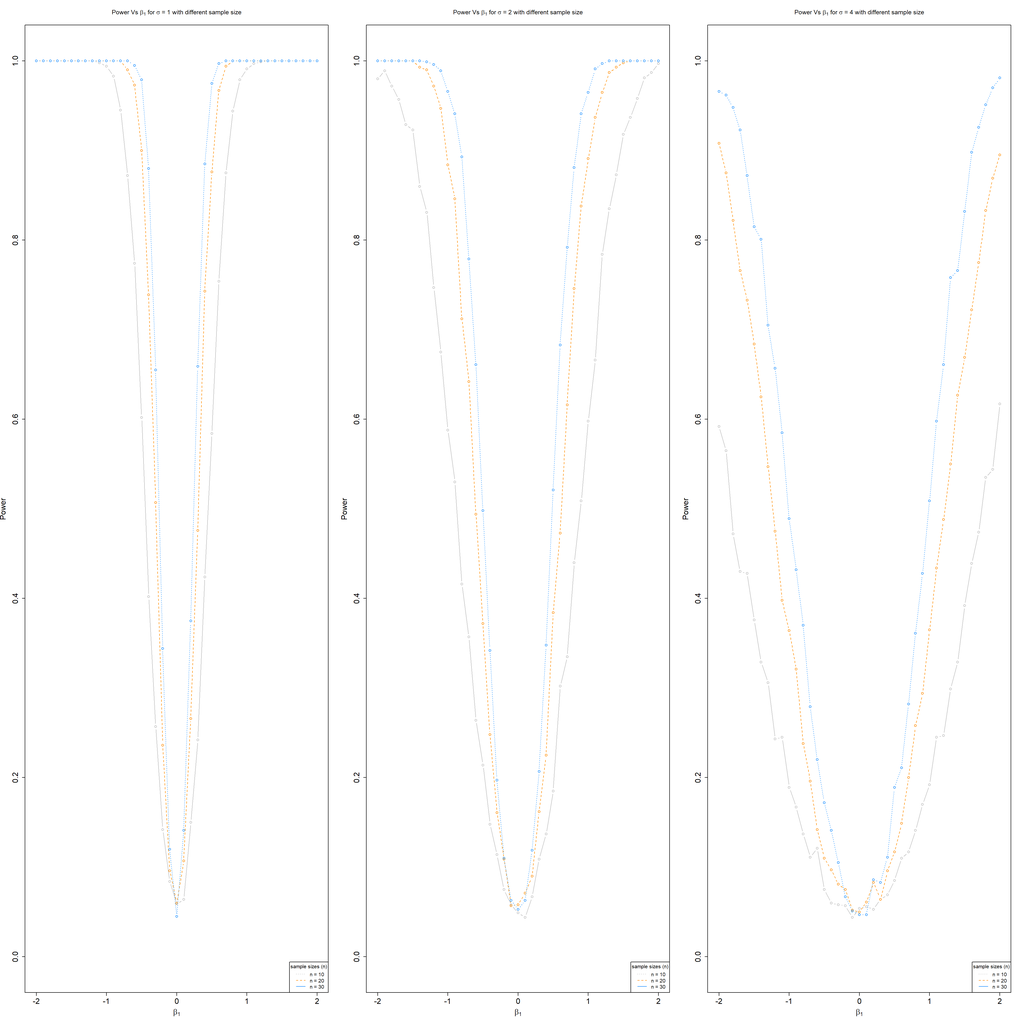

The Figure 2 show that for each value of $n$, the “power curve” for each value of $\sigma$ that shows how power is affected by signal strength, $\beta_1$.

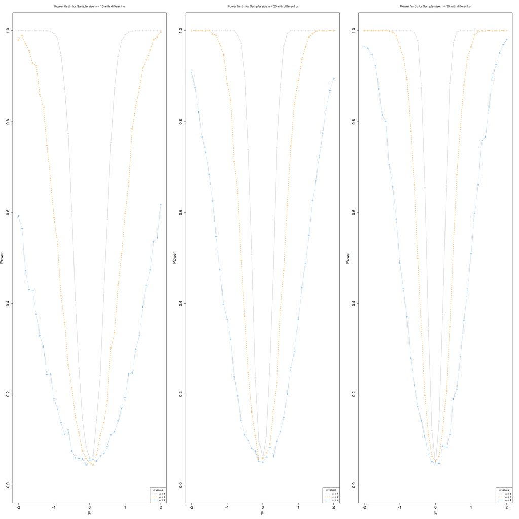

The Figure 3 show the distributions of the $\hat\beta_1$ Values under the Null( $\beta_1$ = 0) and Alternative Hypotheses( $\beta_1$ = 0.5 and $\beta_1$ = 1, two just for comparsion)

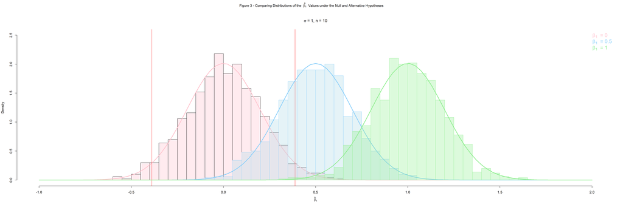

The Figure 4 show t-distributions of the $\hat\beta_1$ Values under the Null( $\beta_1$ = 0) and Alternative Hypotheses( $\beta_1$ = 0.5 and $\beta_1$ = 1, two just for comparsion)

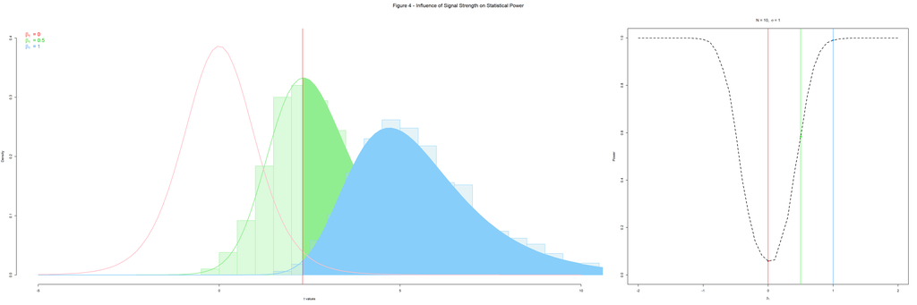

In Figure 5, we compare t-distributions of the $\hat\beta_1$ Values when sample size = 10, and sample size = 20.

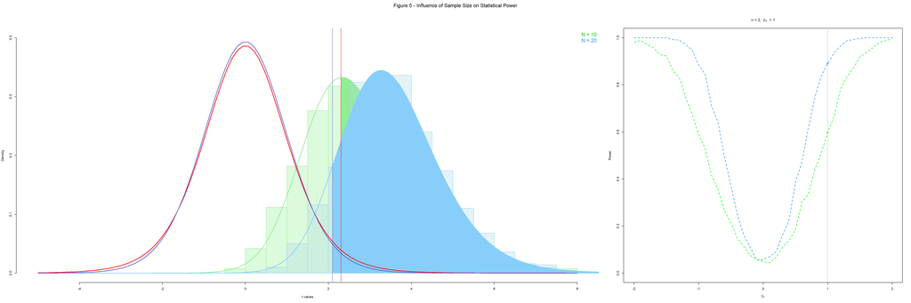

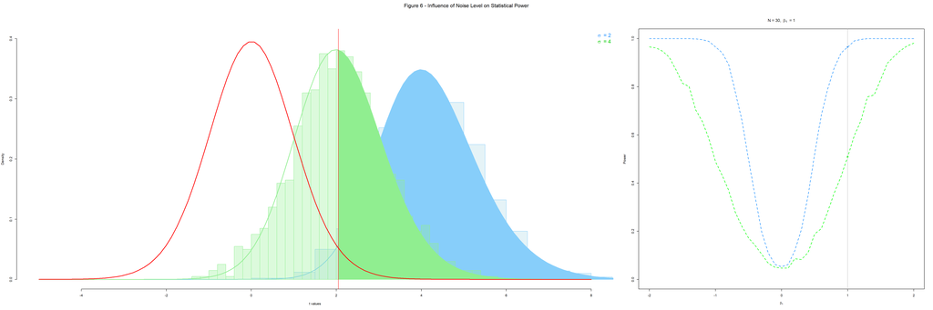

In Figure 7, We see that the empirical and true means and variances are very similar. We also see that the empirical distribution is normal.

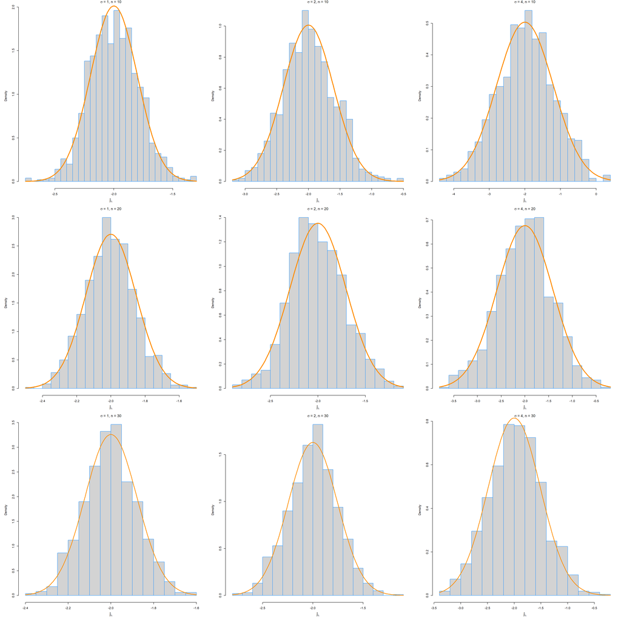

The plot show it clear that the empirical results would get closer and closer to what we should expect. However, there are some exceptions, we will further discuss it later.

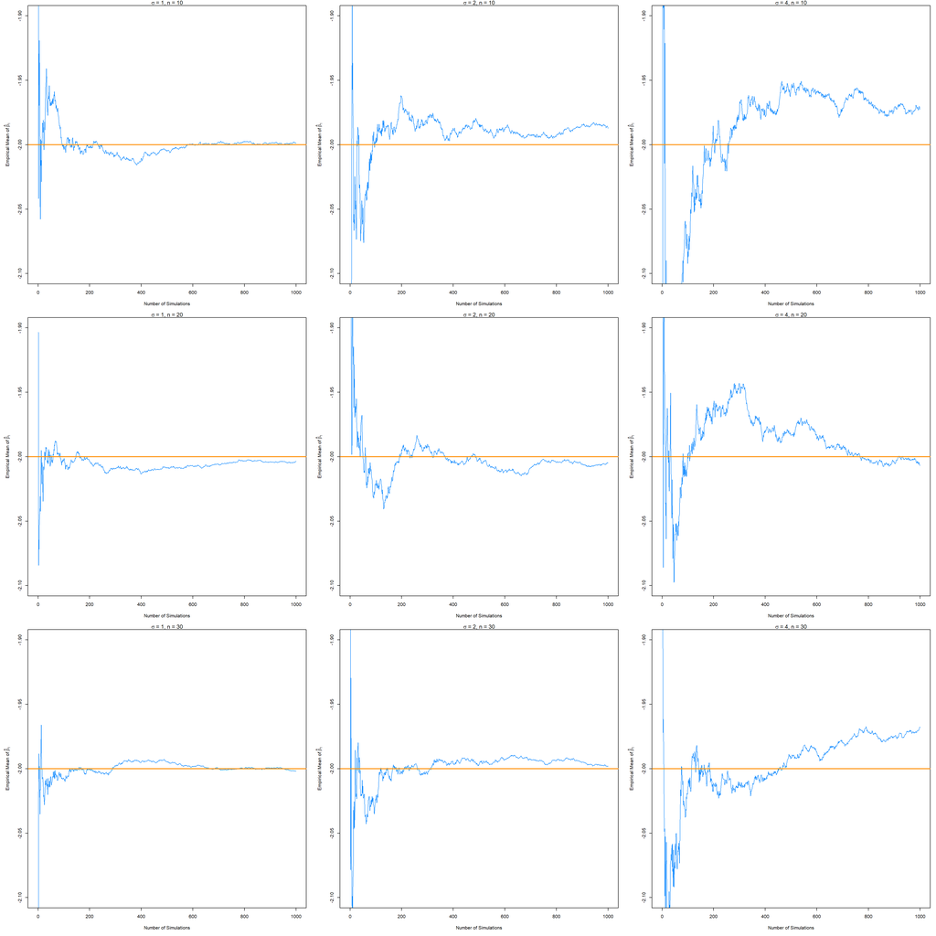

**Discussion**

- How do $n$, $\beta_1$, and $\sigma$ affect power? Consider additional plots to demonstrate these effects.

Reducing $\sigma$ value, increasing $n$, and increasing absolute value of $\beta_1$ will all reduce the overlap of the sampling distributions of the means, thus increasing power.

In both Figure 1 and 2, it demonstrate a clear pattern of symmetry around $\beta_1 = 0$. As the absolute value of $\beta_1$ increases, the statistical power gradually increases from very low (close to 0). At lower $\sigma$ values, the power can reach to 1, while at higher $\sigma$ values, much larger $\beta_1$ values are required for power to approach 1. Increasing $\sigma$ leads to a decrease in power. Within each panel, it is evident that larger sample sizes lead to greater power.

We can see the distributions of $\hat{\beta_1}$ under Null and Alternative hypotheses as shown in Figure 3. Larger signal will shift the $H_1$ curve away from the $H_0$ curve, large $n$ or smaller $\sigma$ will both decrease $SD[\hat{\beta_1}]$ and cause the curves to be narrower and taller.

We used t-value distribution under Null and Alternative hypothesis to understand how these parameters affect power. As shown in Figure 4, the absolute value of $\beta_1$ increases, the non-centrality parameter (ncp) of the t-values under Alternative hypothesis will also increase. The alternative hypothesis t-distribution will shift toward the right, further away from the Null hypothesis t-distribution. This leads to the proportion of the shade area on the right of the critical value will also increase.

In Figure 5, As sample size increases, the shape of the Null hypothesis t-distribution will be taller and narrower, which is very close to normal distribution, with to a smaller critical value. At the same time, because $S\_{xx}$ increases, $SD[\hat{\beta_1}]$ decreases, results ncp to increase, shifting the Alternative hypothesis t-distribution to the right. Together, these effects lead to higher power.

As shown in Figure 6, when $\sigma$ decreases, it decrease $SD[\hat{\beta_1}]$, and thus increase ncp, shift the Alternative hypothesis t-distribution to the right, and increases power.

To summarize, higher statistical power is determined by larger sample sizes, stronger signals, and smaller noises.

- Are $1000$ simulations sufficient?